# Datos Capitulo 3

Ana Solís García

20/4/2022

Datos de la Liga Iberdrola 2020/2021 (https://rfevb-web.dataproject.com/CompetitionHome.aspx?ID=68)

# Liga Iberdrola 2020/2021

```r
library(readxl)
partidos2021 = read_excel("Partidos_20_21.xlsx", sheet = 1, range= "A2:AA266", col_names=T)
head(partidos2021)
```

```
## # A tibble: 6 x 27
##   Equipo         `Sets jugados`   Tot    BP     G `G-P` `Saque-Tot` `Saque-Pts`
##   <chr>                   <dbl> <dbl> <dbl> <dbl> <dbl>       <dbl>       <dbl>
## 1 Cajasol Juvasa              5    71    27    44    30         107           6
## 2 Cajasol Juvasa              4    68    29    39    40          95           3
## 3 Cajasol Juvasa              5    79    37    42    39         102           7
## 4 Cajasol Juvasa              4    58    22    36    20          89           6
## 5 Cajasol Juvasa              3    27    11    16   -10          42           2
## 6 Cajasol Juvasa              3    64    40    24    37          74          12
## # ... with 19 more variables: Saque-Err <dbl>, Saque-Pts por set <dbl>,
## #   Saque-Efic <dbl>, Recep-Tot <dbl>, Recep-Err <dbl>, Recep-Neg <dbl>,
## #   Recep-Exc <dbl>, Recep-ExcPorc <dbl>, Recep-Efic <dbl>, Ataque-Tot <dbl>,
## #   Ataque-Err <dbl>, Ataque-Blo <dbl>, Ataque-Exc <dbl>, Ataque-ExcPorc <dbl>,
## #   Ataque-Efic <dbl>, Bloqueo-Red <dbl>, Bloqueo-Pts <dbl>,
## #   Bloqueo-Puntos por set <dbl>, Ganado/Perdido <dbl>
```

## Estudio descriptivo de los datos

```r
str(partidos2021)
```

```
## tibble [264 x 27] (S3: tbl_df/tbl/data.frame)
##  $ Equipo                : chr [1:264] "Cajasol Juvasa" "Cajasol Juvasa" "Cajasol Juvasa" "Cajasol Juvasa" ...
##  $ Sets jugados          : num [1:264] 5 4 5 4 3 3 5 5 3 4 ...
##  $ Tot                   : num [1:264] 71 68 79 58 27 64 64 75 42 59 ...
##  $ BP                    : num [1:264] 27 29 37 22 11 40 25 33 10 25 ...
##  $ G                     : num [1:264] 44 39 42 36 16 24 39 42 32 34 ...
##  $ G-P                   : num [1:264] 30 40 39 20 -10 37 7 23 11 10 ...
##  $ Saque-Tot             : num [1:264] 107 95 102 89 42 74 81 100 50 82 ...
##  $ Saque-Pts             : num [1:264] 6 3 7 6 2 12 8 4 2 7 ...
##  $ Saque-Err             : num [1:264] 13 9 11 11 3 9 7 14 7 14 ...
##  $ Saque-Pts por set     : num [1:264] 1.2 0.8 1.4 1.5 0.7 4 1.6 0.8 0.7 1.8 ...
##  $ Saque-Efic            : num [1:264] -0.07 -0.06 -0.04 -0.06 -0.02 0.04 0.01 -0.1 -0.1 -0.09 ...
##  $ Recep-Tot             : num [1:264] 100 80 91 89 67 49 104 89 74 84 ...
##  $ Recep-Err             : num [1:264] 9 3 2 6 13 1 13 6 6 10 ...
##  $ Recep-Neg             : num [1:264] 17 34 13 29 12 13 47 24 36 10 ...
##  $ Recep-Exc             : num [1:264] 61 32 61 23 14 20 24 45 16 53 ...
##  $ Recep-ExcPorc         : num [1:264] 0.61 0.4 0.67 0.26 0.21 0.41 0.23 0.51 0.22 0.63 ...
##  $ Recep-Efic            : num [1:264] 0.52 0.36 0.65 0.19 0.01 0.39 0.11 0.44 0.14 0.51 ...
##  $ Ataque-Tot            : num [1:264] 182 134 155 136 98 98 147 169 106 137 ...
##  $ Ataque-Err            : num [1:264] 10 8 19 8 19 7 20 15 10 14 ...
##  $ Ataque-Blo            : num [1:264] 9 8 8 13 2 10 17 17 8 11 ...
##  $ Ataque-Exc            : num [1:264] 54 53 58 43 24 47 44 57 35 43 ...
##  $ Ataque-ExcPorc        : num [1:264] 0.3 0.4 0.37 0.32 0.24 0.48 0.3 0.34 0.33 0.31 ...
##  $ Ataque-Efic           : num [1:264] 0.19 0.28 0.2 0.16 0.03 0.31 0.05 0.15 0.16 0.13 ...
##  $ Bloqueo-Red           : num [1:264] 0 0 0 0 0 0 0 0 0 0 ...
##  $ Bloqueo-Pts           : num [1:264] 11 12 14 9 1 5 12 14 5 9 ...
##  $ Bloqueo-Puntos por set: num [1:264] 2.2 3 2.8 2.3 0.3 1.7 2.4 2.8 1.7 2.3 ...
##  $ Ganado/Perdido        : num [1:264] 0 1 0 0 0 1 0 0 0 0 ...
```

Primero cambiamos la variable *Ganado/Perdido* a una variable dicotómica de tipo factor con valores 0 y 1 correspondientes a si el equipo ha perdido o ha ganado el partido.

```r
partidos2021$`Ganado/Perdido` = as.factor(partidos2021$`Ganado/Perdido`)
str(partidos2021)
```

```
## tibble [264 x 27] (S3: tbl_df/tbl/data.frame)
##  $ Equipo                : chr [1:264] "Cajasol Juvasa" "Cajasol Juvasa" "Cajasol Juvasa" "Cajasol Juvasa" ...
##  $ Sets jugados          : num [1:264] 5 4 5 4 3 3 5 5 3 4 ...
##  $ Tot                   : num [1:264] 71 68 79 58 27 64 64 75 42 59 ...
##  $ BP                    : num [1:264] 27 29 37 22 11 40 25 33 10 25 ...
##  $ G                     : num [1:264] 44 39 42 36 16 24 39 42 32 34 ...
##  $ G-P                   : num [1:264] 30 40 39 20 -10 37 7 23 11 10 ...
##  $ Saque-Tot             : num [1:264] 107 95 102 89 42 74 81 100 50 82 ...
##  $ Saque-Pts             : num [1:264] 6 3 7 6 2 12 8 4 2 7 ...
##  $ Saque-Err             : num [1:264] 13 9 11 11 3 9 7 14 7 14 ...
##  $ Saque-Pts por set     : num [1:264] 1.2 0.8 1.4 1.5 0.7 4 1.6 0.8 0.7 1.8 ...
##  $ Saque-Efic            : num [1:264] -0.07 -0.06 -0.04 -0.06 -0.02 0.04 0.01 -0.1 -0.1 -0.09 ...
##  $ Recep-Tot             : num [1:264] 100 80 91 89 67 49 104 89 74 84 ...
##  $ Recep-Err             : num [1:264] 9 3 2 6 13 1 13 6 6 10 ...
##  $ Recep-Neg             : num [1:264] 17 34 13 29 12 13 47 24 36 10 ...
##  $ Recep-Exc             : num [1:264] 61 32 61 23 14 20 24 45 16 53 ...
##  $ Recep-ExcPorc         : num [1:264] 0.61 0.4 0.67 0.26 0.21 0.41 0.23 0.51 0.22 0.63 ...
##  $ Recep-Efic            : num [1:264] 0.52 0.36 0.65 0.19 0.01 0.39 0.11 0.44 0.14 0.51 ...
##  $ Ataque-Tot            : num [1:264] 182 134 155 136 98 98 147 169 106 137 ...
##  $ Ataque-Err            : num [1:264] 10 8 19 8 19 7 20 15 10 14 ...
##  $ Ataque-Blo            : num [1:264] 9 8 8 13 2 10 17 17 8 11 ...
##  $ Ataque-Exc            : num [1:264] 54 53 58 43 24 47 44 57 35 43 ...
##  $ Ataque-ExcPorc        : num [1:264] 0.3 0.4 0.37 0.32 0.24 0.48 0.3 0.34 0.33 0.31 ...
##  $ Ataque-Efic           : num [1:264] 0.19 0.28 0.2 0.16 0.03 0.31 0.05 0.15 0.16 0.13 ...
##  $ Bloqueo-Red           : num [1:264] 0 0 0 0 0 0 0 0 0 0 ...
##  $ Bloqueo-Pts           : num [1:264] 11 12 14 9 1 5 12 14 5 9 ...
##  $ Bloqueo-Puntos por set: num [1:264] 2.2 3 2.8 2.3 0.3 1.7 2.4 2.8 1.7 2.3 ...
##  $ Ganado/Perdido        : Factor w/ 2 levels "0","1": 1 2 1 1 1 2 1 1 1 1 ...
```

```r
dim(partidos2021)
```

```
## [1] 264  27
```

```r
summary(partidos2021)
```

```
##     Equipo           Sets jugados        Tot              BP
##  Length:264         Min.   :3.000   Min.   :24.00   Min.   : 5.00
##  Class :character   1st Qu.:3.000   1st Qu.:51.75   1st Qu.:19.00
##  Mode  :character   Median :4.000   Median :60.00   Median :26.00
##                     Mean   :3.818   Mean   :60.40   Mean   :24.85
##                     3rd Qu.:4.250   3rd Qu.:73.00   3rd Qu.:31.00
##                     Max.   :5.000   Max.   :92.00   Max.   :44.00
##        G              G-P           Saque-Tot        Saque-Pts
##  Min.   :16.00   Min.   :-10.00   Min.   : 42.00   Min.   : 0.00
##  1st Qu.:28.00   1st Qu.: 17.00   1st Qu.: 73.00   1st Qu.: 3.00
##  Median :35.00   Median : 30.00   Median : 82.00   Median : 4.00
##  Mean   :35.55   Mean   : 26.35   Mean   : 83.02   Mean   : 4.75
##  3rd Qu.:42.00   3rd Qu.: 37.00   3rd Qu.: 98.00   3rd Qu.: 6.00
##  Max.   :63.00   Max.   : 57.00   Max.   :117.00   Max.   :13.00
##    Saque-Err      Saque-Pts por set   Saque-Efic       Recep-Tot
##  Min.   : 0.000   Min.   :0.00      Min.   :-0.170   Min.   : 37.00
##  1st Qu.: 6.000   1st Qu.:0.80      1st Qu.:-0.090   1st Qu.: 62.75
##  Median : 8.000   Median :1.10      Median :-0.045   Median : 73.50
##  Mean   : 8.746   Mean   :1.27      Mean   :-0.050   Mean   : 74.24
##  3rd Qu.:11.000   3rd Qu.:1.70      3rd Qu.:-0.020   3rd Qu.: 88.25
##  Max.   :20.000   Max.   :4.30      Max.   : 0.100   Max.   :108.00
##    Recep-Err        Recep-Neg       Recep-Exc     Recep-ExcPorc
##  Min.   : 0.000   Min.   : 3.00   Min.   : 5.00   Min.   :0.0800
##  1st Qu.: 3.000   1st Qu.:15.00   1st Qu.:20.00   1st Qu.:0.3000
##  Median : 4.000   Median :21.00   Median :26.00   Median :0.3650
##  Mean   : 4.742   Mean   :21.28   Mean   :28.45   Mean   :0.3849
##  3rd Qu.: 6.000   3rd Qu.:27.00   3rd Qu.:34.00   3rd Qu.:0.4700
##  Max.   :13.000   Max.   :47.00   Max.   :63.00   Max.   :0.7100
##    Recep-Efic      Ataque-Tot      Ataque-Err      Ataque-Blo
##  Min.   :0.000   Min.   : 73.0   Min.   : 1.00   Min.   : 1.000
##  1st Qu.:0.240   1st Qu.:104.0   1st Qu.: 8.00   1st Qu.: 6.750
##  Median :0.305   Median :126.5   Median :11.00   Median : 9.000
##  Mean   :0.321   Mean   :130.0   Mean   :11.44   Mean   : 9.129
##  3rd Qu.:0.400   3rd Qu.:155.0   3rd Qu.:15.00   3rd Qu.:11.000
##  Max.   :0.670   Max.   :214.0   Max.   :24.00   Max.   :26.000
##    Ataque-Exc    Ataque-ExcPorc    Ataque-Efic      Bloqueo-Red
##  Min.   :22.00   Min.   :0.2200   Min.   :0.0000   Min.   :0.00000
##  1st Qu.:38.00   1st Qu.:0.3200   1st Qu.:0.1500   1st Qu.:0.00000
##  Median :45.00   Median :0.3600   Median :0.2000   Median :0.00000
##  Mean   :46.53   Mean   :0.3617   Mean   :0.2029   Mean   :0.02652
##  3rd Qu.:56.00   3rd Qu.:0.4000   3rd Qu.:0.2525   3rd Qu.:0.00000
##  Max.   :74.00   Max.   :0.5500   Max.   :0.4300   Max.   :2.00000
##   Bloqueo-Pts     Bloqueo-Puntos por set Ganado/Perdido
##  Min.   : 1.000   Min.   :0.30           0:133
##  1st Qu.: 6.750   1st Qu.:1.80           1:131
##  Median : 9.000   Median :2.30
##  Mean   : 9.125   Mean   :2.42
##  3rd Qu.:11.000   3rd Qu.:3.00
##  Max.   :26.000   Max.   :5.70
```

## Estudio de las variables

Finalmente, tenemos una base de datos con las estadísticas correspondientes a los partidos de la fase regular en los que participaron los 12 equipos de la liga. Está compuesta por 264 registros con 27 variables. Las variables con las que se ha trabajado en este estudio son las siguientes:

- Variables cuantitativas discretas
  - Sets jugados
  - Tot (puntos totales ganados en el partido)
  - BP
  - G
  - G-P
  - Saque-Tot
  - Saque-Pts
  - Saque-Err
  - Recep-Tot
  - Recep-Err
  - Recep-Neg
  - Recep-Exc
  - Ataque-Tot
  - Ataque-Err
  - Ataque-Blo
  - Ataque-Exc
  - Bloqueo-Red
  - Bloqueo-Pts
- Variables cuantitativas continuas
  - Saque-Pts por set
  - Saque-Efic
  - Recep-Exc%: porcentaje de recepciones perfectas con respecto al total.
  - Recep-Efic: diferencia entre el número de recepciones perfectas y el número de recepciones falladas con respecto al total de recepciones en porcentaje.
  - Ataque-Exc%: porcentaje de ataques perfectos.
  - Ataque-Efic: diferencia entre el número de ataques perfectos y el número de ataques fallados y bloqueados con respecto al total de recepciones en porcentaje.
  - Bloqueo-Pts por set
- Variables cualitativas discretas
  - Equipo
  - Ganado/Perdido

# VARIABLES SELECCIONADAS

```r
dat = partidos2021[,c(1:2,4:5,7:9,12:15,18:21,24:25,27)]
str(dat)
```

```
## tibble [264 x 18] (S3: tbl_df/tbl/data.frame)
##  $ Equipo        : chr [1:264] "Cajasol Juvasa" "Cajasol Juvasa" "Cajasol Juvasa" "Cajasol Juvasa" ...
##  $ Sets jugados  : num [1:264] 5 4 5 4 3 3 5 5 3 4 ...
##  $ BP            : num [1:264] 27 29 37 22 11 40 25 33 10 25 ...
##  $ G             : num [1:264] 44 39 42 36 16 24 39 42 32 34 ...
##  $ Saque-Tot     : num [1:264] 107 95 102 89 42 74 81 100 50 82 ...
##  $ Saque-Pts     : num [1:264] 6 3 7 6 2 12 8 4 2 7 ...
##  $ Saque-Err     : num [1:264] 13 9 11 11 3 9 7 14 7 14 ...
##  $ Recep-Tot     : num [1:264] 100 80 91 89 67 49 104 89 74 84 ...
##  $ Recep-Err     : num [1:264] 9 3 2 6 13 1 13 6 6 10 ...
##  $ Recep-Neg     : num [1:264] 17 34 13 29 12 13 47 24 36 10 ...
##  $ Recep-Exc     : num [1:264] 61 32 61 23 14 20 24 45 16 53 ...
##  $ Ataque-Tot    : num [1:264] 182 134 155 136 98 98 147 169 106 137 ...
##  $ Ataque-Err    : num [1:264] 10 8 19 8 19 7 20 15 10 14 ...
##  $ Ataque-Blo    : num [1:264] 9 8 8 13 2 10 17 17 8 11 ...
##  $ Ataque-Exc    : num [1:264] 54 53 58 43 24 47 44 57 35 43 ...
##  $ Bloqueo-Red   : num [1:264] 0 0 0 0 0 0 0 0 0 0 ...
##  $ Bloqueo-Pts   : num [1:264] 11 12 14 9 1 5 12 14 5 9 ...
##  $ Ganado/Perdido: Factor w/ 2 levels "0","1": 1 2 1 1 1 2 1 1 1 1 ...
```

### Gráficos y análisis de las variables

#### Boxplot

```r
library(ggplot2)
library(dplyr)
library(tidyverse)
# CAMBIAMOS A FORMATO LARGO PARA HACER BOXPLOT DE LAS VARIABLES
partidos_boxplot1 = dat[,c(2:9)] %>%
  pivot_longer(names_to = "Variables",
               values_to = "Valores", cols=everything())
head(partidos_boxplot1)
```

```
## # A tibble: 6 x 2
##   Variables    Valores
##   <chr>          <dbl>
## 1 Sets jugados       5
## 2 BP                27
## 3 G                 44
## 4 Saque-Tot        107
## 5 Saque-Pts          6
## 6 Saque-Err         13
```

```r
partidos_boxplot2 = dat[,c(10:17)] %>%
  pivot_longer(names_to = "Variables",
               values_to = "Valores", cols=everything())
head(partidos_boxplot2)
```

```
## # A tibble: 6 x 2
##   Variables  Valores
##   <chr>        <dbl>
## 1 Recep-Neg       17
## 2 Recep-Exc       61
## 3 Ataque-Tot     182
## 4 Ataque-Err      10
## 5 Ataque-Blo       9
## 6 Ataque-Exc      54
```

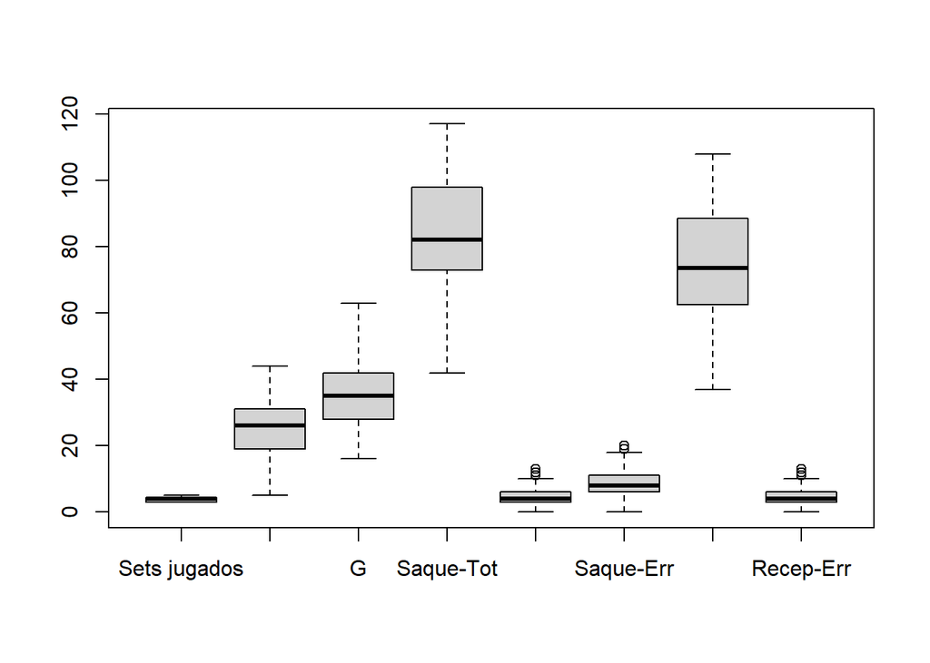

```r
boxplot(dat[,2:9])
```

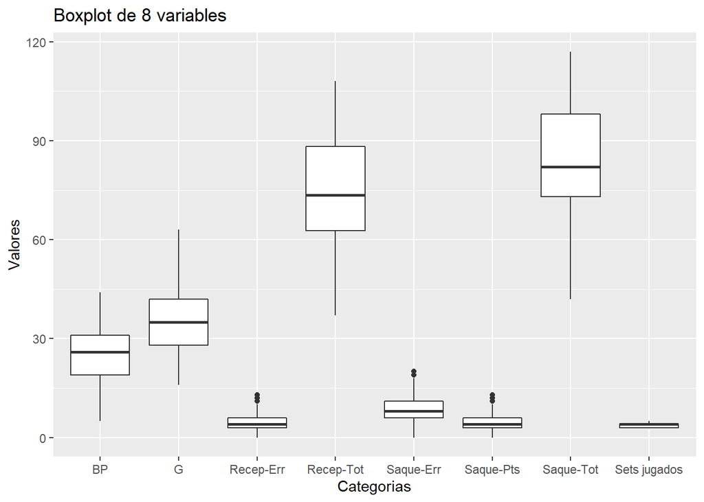

```r
partidos_boxplot1 %>%
  ggplot(aes(x=`Variables` , y=Valores)) +
  geom_boxplot() +
  labs(
    title="Boxplot de 8 variables",
    x="Categorias",
    y="Valores")
```

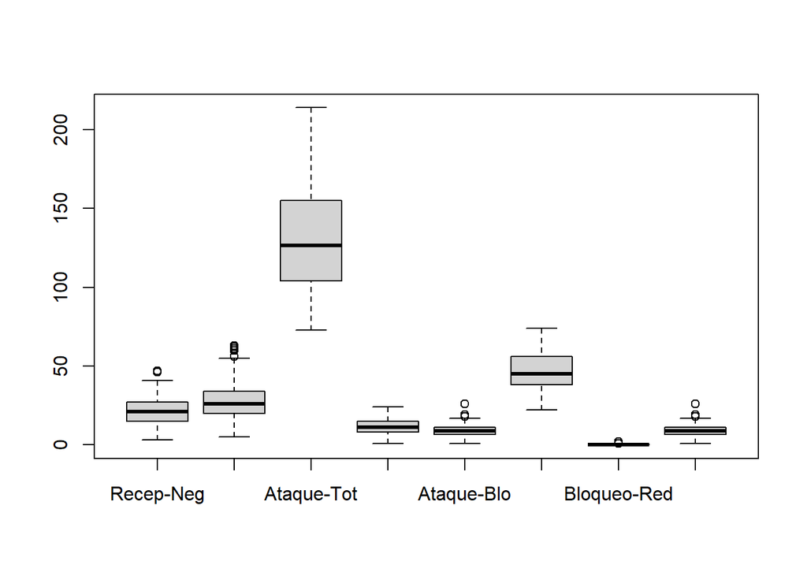

```r
boxplot(dat[,10:17])
```

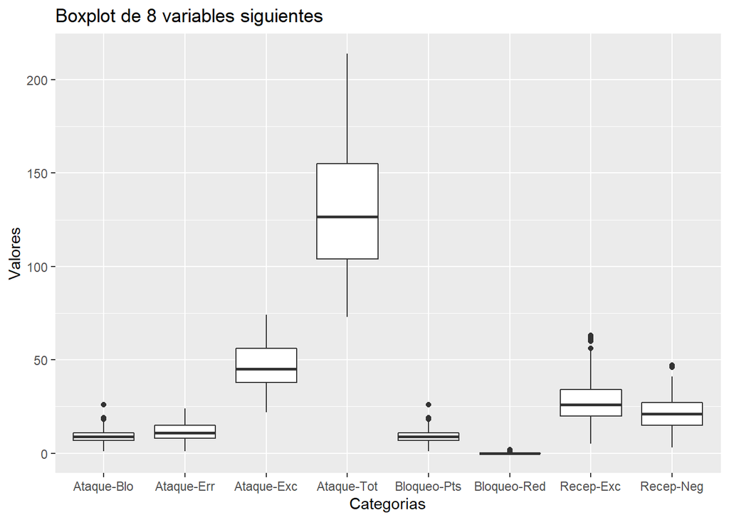

```r
partidos_boxplot2 %>%
  ggplot(aes(x=Variables , y=Valores)) +
  geom_boxplot() +
  labs(
    title="Boxplot de 8 variables siguientes",
    x="Categorias",
    y="Valores")
```

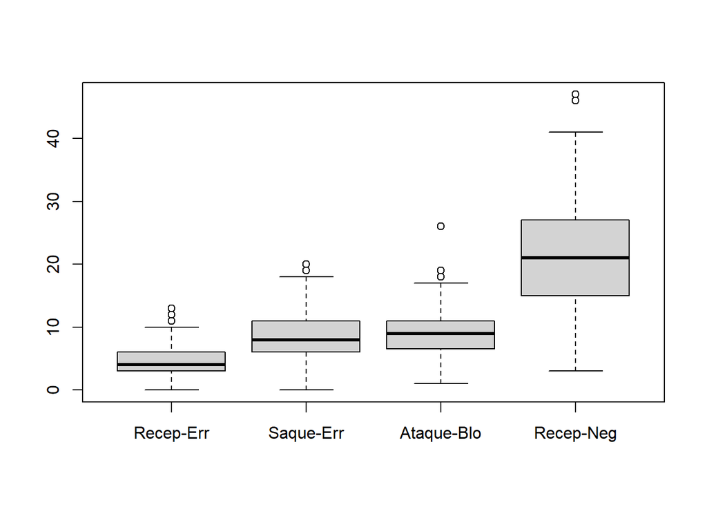

```r
boxplot(dat[c("Recep-Err","Saque-Err", "Ataque-Blo" ,"Recep-Neg")])
```

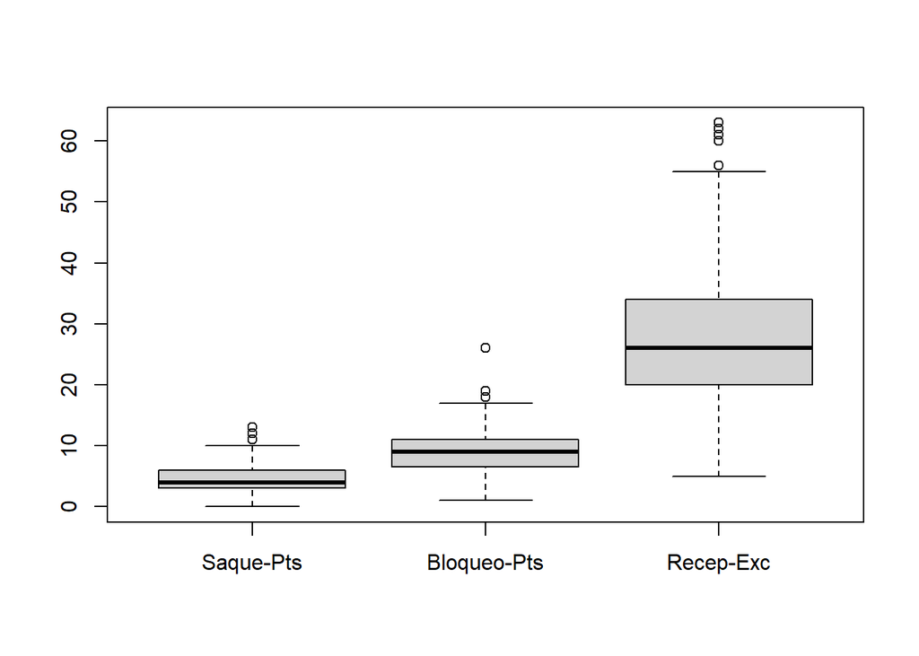

```r
boxplot(dat[c("Saque-Pts","Bloqueo-Pts","Recep-Exc")])
```

Para ambos análisis podemos encontrar variables que presentan valores ‘outliers’, los cuales podrían afectar a nuestro estudio.

#### Matriz varianzas y correlaciones

Analizamos ahora la matriz de varianzas/covarianzas y la matriz de correlaciones para ver qué variables pueden verse afectadas por los valores de otras.

```r
var(dat[,c(2:17)])
```

```
##              Sets jugados           BP           G   Saque-Tot   Saque-Pts
## Sets jugados   0.65122710   3.27341860   6.1192534  12.9989630  0.54372624
## BP             3.27341860  65.66250432  30.3780245 113.1505358 14.01615970
## G              6.11925337  30.37802454  86.1800755 141.4327111  3.84505703
## Saque-Tot     12.99896301 113.15053578 141.4327111 340.5549026 20.19011407
## Saque-Pts      0.54372624  14.01615970   3.8450570  20.1901141  7.56463878
## Saque-Err      1.31489803   6.62016073  15.3414420  27.6122249  1.52186312
## Recep-Tot     11.70203941  18.57587280 126.5773707 200.7567692  0.01520913
## Recep-Err      0.55375043  -3.12184583   2.0925798   1.3879479 -0.78707224
## Recep-Neg      2.94400277  -5.28218977  27.2581951  35.2581519 -1.63403042
## Recep-Exc      5.59557553  27.10106291  61.1849435 115.5026501  5.21958175
## Ataque-Tot    20.90183201 105.16786208 234.7621702 445.3877751 10.97433460
## Ataque-Err     1.74179053   1.55565157  17.5828436  25.3773476 -0.78326996
## Ataque-Blo     1.23263049   0.46776702  12.1875504  17.9067865 -0.02091255
## Ataque-Exc     7.60559972  65.05526270  98.3180810 196.9273534  8.50855513
## Bloqueo-Red   -0.01797442  -0.09112513  -0.2351509  -0.3578177 -0.01235741
## Bloqueo-Pts    1.24334601  16.96910646  14.3949620  37.4657795  1.78802281
##                Saque-Err    Recep-Tot   Recep-Err  Recep-Neg   Recep-Exc
## Sets jugados  1.31489803  11.70203941  0.55375043  2.9440028   5.5955755
## BP            6.62016073  18.57587280 -3.12184583 -5.2821898  27.1010629
## G            15.34144199 126.57737066  2.09257979 27.2581951  61.1849435
## Saque-Tot    27.61222491 200.75676921  1.38794792 35.2581519 115.5026501
## Saque-Pts     1.52186312   0.01520913 -0.78707224 -1.6340304   5.2195817
## Saque-Err    13.41443427  25.17962899  1.21955294  6.8955381  13.1642614
## Recep-Tot    25.17962899 299.49994239 18.89918193 88.2026731 113.3808042
## Recep-Err     1.21955294  18.89918193  7.59880171  7.2273879   4.4131236
## Recep-Neg     6.89553808  88.20267312  7.22738795 68.9460623   1.7380027
## Recep-Exc    13.16426144 113.38080424  4.41312363  1.7380027 127.6553606
## Ataque-Tot   34.24811326 448.86599839 10.58272842 93.2955266 214.6674876
## Ataque-Err    1.18418021  49.39877866  1.52045166 13.6575066  15.9456735
## Ataque-Blo    2.15448208  35.28424934  1.79755732 12.0859258  12.8732861
## Ataque-Exc   18.32424530 129.11141837 -0.30112916 19.6409293  73.6438962
## Bloqueo-Red  -0.08069766  -0.59200369 -0.05778315 -0.1556487  -0.3427958
## Bloqueo-Pts   2.11549430  16.02661597  0.05893536  3.9691065   9.4225285
##               Ataque-Tot Ataque-Err  Ataque-Blo  Ataque-Exc Bloqueo-Red
## Sets jugados  20.9018320  1.7417905  1.23263049   7.6055997 -0.01797442
## BP           105.1678621  1.5556516  0.46776702  65.0552627 -0.09112513
## G            234.7621702 17.5828436 12.18755041  98.3180810 -0.23515094
## Saque-Tot    445.3877751 25.3773476 17.90678650 196.9273534 -0.35781772
## Saque-Pts     10.9743346 -0.7832700 -0.02091255   8.5085551 -0.01235741
```

[output cut: 13 more lines]

```
## BP           16.96910646
## G            14.39496198
## Saque-Tot    37.46577947
## Saque-Pts     1.78802281
## Saque-Err     2.11549430
## Recep-Tot    16.02661597
## Recep-Err     0.05893536
## Recep-Neg     3.96910646
## Recep-Exc     9.42252852
## Ataque-Tot   35.76378327
## Ataque-Err    1.06273764
## Ataque-Blo    0.53136882
## Ataque-Exc   15.89971483
## Bloqueo-Red  -0.02994297
## Bloqueo-Pts  13.67633080
```

```r
cor = cor(dat[,2:17])
round(cor,3)
```

```
##              Sets jugados     BP      G Saque-Tot Saque-Pts Saque-Err Recep-Tot
## Sets jugados        1.000  0.501  0.817     0.873     0.245     0.445     0.838
## BP                  0.501  1.000  0.404     0.757     0.629     0.223     0.132
## G                   0.817  0.404  1.000     0.826     0.151     0.451     0.788
## Saque-Tot           0.873  0.757  0.826     1.000     0.398     0.409     0.629
## Saque-Pts           0.245  0.629  0.151     0.398     1.000     0.151     0.000
## Saque-Err           0.445  0.223  0.451     0.409     0.151     1.000     0.397
## Recep-Tot           0.838  0.132  0.788     0.629     0.000     0.397     1.000
## Recep-Err           0.249 -0.140  0.082     0.027    -0.104     0.121     0.396
## Recep-Neg           0.439 -0.079  0.354     0.230    -0.072     0.227     0.614
## Recep-Exc           0.614  0.296  0.583     0.554     0.168     0.318     0.580
## Ataque-Tot          0.830  0.416  0.810     0.773     0.128     0.300     0.831
## Ataque-Err          0.476  0.042  0.418     0.303    -0.063     0.071     0.630
## Ataque-Blo          0.412  0.016  0.354     0.262    -0.002     0.159     0.550
## Ataque-Exc          0.799  0.681  0.898     0.905     0.262     0.424     0.633
## Bloqueo-Red        -0.110 -0.055 -0.125    -0.096    -0.022    -0.109    -0.169
## Bloqueo-Pts         0.417  0.566  0.419     0.549     0.176     0.156     0.250
##              Recep-Err Recep-Neg Recep-Exc Ataque-Tot Ataque-Err Ataque-Blo
## Sets jugados     0.249     0.439     0.614      0.830      0.476      0.412
## BP              -0.140    -0.079     0.296      0.416      0.042      0.016
## G                0.082     0.354     0.583      0.810      0.418      0.354
## Saque-Tot        0.027     0.230     0.554      0.773      0.303      0.262
## Saque-Pts       -0.104    -0.072     0.168      0.128     -0.063     -0.002
## Saque-Err        0.121     0.227     0.318      0.300      0.071      0.159
## Recep-Tot        0.396     0.614     0.580      0.831      0.630      0.550
## Recep-Err        1.000     0.316     0.142      0.123      0.122      0.176
## Recep-Neg        0.316     1.000     0.019      0.360      0.363      0.392
## Recep-Exc        0.142     0.019     1.000      0.609      0.311      0.307
## Ataque-Tot       0.123     0.360     0.609      1.000      0.621      0.455
## Ataque-Err       0.122     0.363     0.311      0.621      1.000      0.276
## Ataque-Blo       0.176     0.392     0.307      0.455      0.276      1.000
## Ataque-Exc      -0.009     0.201     0.553      0.797      0.353      0.278
## Bloqueo-Red     -0.103    -0.092    -0.150     -0.124     -0.116     -0.050
## Bloqueo-Pts      0.006     0.129     0.226      0.310      0.063      0.039
##              Ataque-Exc Bloqueo-Red Bloqueo-Pts
## Sets jugados      0.799      -0.110       0.417
## BP                0.681      -0.055       0.566
## G                 0.898      -0.125       0.419
## Saque-Tot         0.905      -0.096       0.549
## Saque-Pts         0.262      -0.022       0.176
## Saque-Err         0.424      -0.109       0.156
## Recep-Tot         0.633      -0.169       0.250
## Recep-Err        -0.009      -0.103       0.006
## Recep-Neg         0.201      -0.092       0.129
## Recep-Exc         0.553      -0.150       0.226
## Ataque-Tot        0.797      -0.124       0.310
## Ataque-Err        0.353      -0.116       0.063
## Ataque-Blo        0.278      -0.050       0.039
## Ataque-Exc        1.000      -0.119       0.365
## Bloqueo-Red      -0.119       1.000      -0.040
## Bloqueo-Pts       0.365      -0.040       1.000
```

Para ver si hay variables explicativas que se encuentren muy correlacionadas realizamos el determinante de la matriz de correlaciones

```r
det(cor)
```

```
## [1] 1.832815e-21
```

Tiene un valor muy próximo a cero luego eso significa que hay variables en las que existe una alta correlación entre ellas.

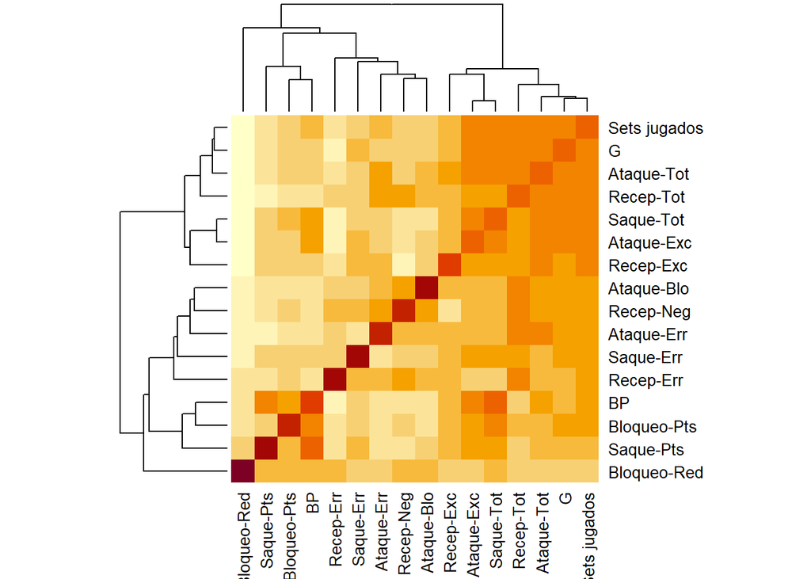

```r
heatmap(cor)
```

```r
# variables mas correlacionadas
variables = colnames(dat[,2:17])
correlacionMax=0.85
corAltas = matrix (ncol = 3)
cor[lower.tri(cor)] <- NA #pasamos a una matriz triangular superior para que no nos salgan pares repetidos
for (i in 1:dim(cor)[1]){
    for (j in 1:dim(cor)[2]){
        if (is.na(cor[j,i]) && abs(cor[i,j])>correlacionMax && cor[i,j]<1){
          corAltas = rbind(corAltas, c(variables[i],variables[j],round(cor[i,j],4)))
        }
    }
}
(paresVariables = as.data.frame(corAltas[-1,]))
```

```
##             V1         V2     V3
## 1 Sets jugados  Saque-Tot 0.8729
## 2            G Ataque-Exc 0.8984
## 3    Saque-Tot Ataque-Exc 0.9052
```

```r
library(knitr)
library(kableExtra)
kable(paresVariables, booktabs = T) %>% # , format = "latex"
kable_styling(latex_options = c( "scale_down"))
```

| V1 | V2 | V3 |
| --- | --- | --- |
| Sets jugados | Saque-Tot | 0.8729 |
| G | Ataque-Exc | 0.8984 |
| Saque-Tot | Ataque-Exc | 0.9052 |

Esto puede indicar que existe un problema de multicolinealidad, en el que hay variables que me aportan información similar, luego esto puede dar lugar a interpretaciones erróneas. Para ello puede ser de gran ayuda un análisis de componentes principales.

### Análisis de componentes principales

*Objetivo central del Análisis de Comp. Principales (ACP): reducir la dimensión de un conjunto de datos, descritos por un número elevado de variables aleatorias interrelacionadas entre sí, reteniendo tanto como sea posible la variación que presenta dicho conjunto de datos. Se trata de explicar la estructura de varianzas y covarianzas del conjunto de variables a través de otro conjunto de variables, con un cardinal considerablemente menor que el primero. Así se podrá reducir dimensión, además de interpretar los datos*

Su construcción no requiere supuesto de normalidad. No obstante, en poblaciones normales se pueden realizar tests de hipótesis y proporcionan interpretaciones útiles de los elipsoides de densidad constante.

```r
cor =cor(dat[,2:17])
acp = princomp(dat[,2:17], cor=TRUE) #cor=TRUE variables tipificadas ya que las escalas son muy distintas
summary(acp)
```

```
## Importance of components:
##                           Comp.1    Comp.2     Comp.3     Comp.4     Comp.5
## Standard deviation     2.6330709 1.5292513 1.03412326 1.00048441 0.95011628
## Proportion of Variance 0.4333164 0.1461631 0.06683818 0.06256057 0.05642006
## Cumulative Proportion  0.4333164 0.5794795 0.64631768 0.70887825 0.76529831
##                           Comp.6     Comp.7    Comp.8     Comp.9    Comp.10
## Standard deviation     0.9163127 0.88946338 0.8280396 0.69247868 0.61036833
## Proportion of Variance 0.0524768 0.04944657 0.0428531 0.02997042 0.02328434
## Cumulative Proportion  0.8177751 0.86722168 0.9100748 0.94004520 0.96332954
##                           Comp.11     Comp.12     Comp.13     Comp.14
## Standard deviation     0.47505349 0.394769481 0.350841574 0.208831622
## Proportion of Variance 0.01410474 0.009740184 0.007693113 0.002725665
## Cumulative Proportion  0.97743428 0.987174466 0.994867579 0.997593245
##                            Comp.15      Comp.16
## Standard deviation     0.196234768 2.980232e-08
## Proportion of Variance 0.002406755 5.551115e-17
## Cumulative Proportion  1.000000000 1.000000e+00
```

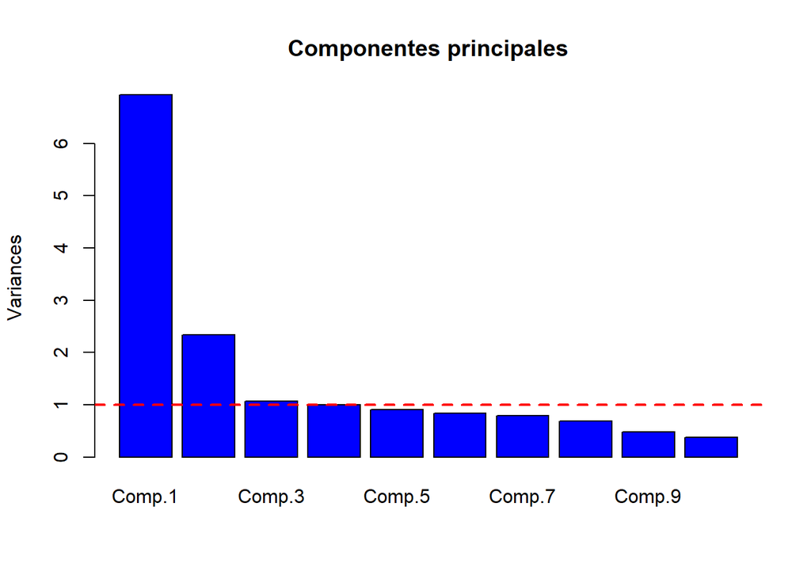

```r
# grafico de sedimentacion
plot(acp, col="blue", main = "Componentes principales")
abline(h=mean(eigen(cor)$values), lwd=2,lty=2, col="red")
```

```r
resumen<- matrix(NA,nrow=length(acp$sdev),ncol=3)
resumen[,1]<-  acp$sdev^2 # eigen(cor)$values
resumen[,2]<- 100*resumen[,1]/sum(resumen[,1])
resumen[,3]<- cumsum(resumen[,2])
colnames(resumen)<- c("Autovalor","Porcentaje",
                      "Porcentaje acumulado")
resumen
```

```
##          Autovalor   Porcentaje Porcentaje acumulado
##  [1,] 6.933063e+00 4.333164e+01             43.33164
##  [2,] 2.338610e+00 1.461631e+01             57.94795
##  [3,] 1.069411e+00 6.683818e+00             64.63177
##  [4,] 1.000969e+00 6.256057e+00             70.88782
##  [5,] 9.027209e-01 5.642006e+00             76.52983
##  [6,] 8.396289e-01 5.247680e+00             81.77751
##  [7,] 7.911451e-01 4.944657e+00             86.72217
##  [8,] 6.856496e-01 4.285310e+00             91.00748
##  [9,] 4.795267e-01 2.997042e+00             94.00452
## [10,] 3.725495e-01 2.328434e+00             96.33295
## [11,] 2.256758e-01 1.410474e+00             97.74343
## [12,] 1.558429e-01 9.740184e-01             98.71745
## [13,] 1.230898e-01 7.693113e-01             99.48676
## [14,] 4.361065e-02 2.725665e-01             99.75932
## [15,] 3.850808e-02 2.406755e-01            100.00000
## [16,] 8.881784e-16 5.551115e-15            100.00000
```

Hasta la 8 tenemos un 90% de la variabilidad explicada

Contraste de hipótesis para seleccionar el número de componentes principales (bajo hipótesis de normalidad multivariante)

```r
apply(dat[,2:17],2 ,shapiro.test)
```

```
## $`Sets jugados`
##
##  Shapiro-Wilk normality test
##
## data:  newX[, i]
## W = 0.7787, p-value < 2.2e-16
##
##
## $BP
##
##  Shapiro-Wilk normality test
##
## data:  newX[, i]
## W = 0.97866, p-value = 0.0005389
##
##
## $G
##
##  Shapiro-Wilk normality test
##
## data:  newX[, i]
## W = 0.98404, p-value = 0.004777
##
##
## $`Saque-Tot`
##
##  Shapiro-Wilk normality test
##
## data:  newX[, i]
## W = 0.9659, p-value = 6.425e-06
##
##
## $`Saque-Pts`
##
##  Shapiro-Wilk normality test
##
## data:  newX[, i]
## W = 0.93232, p-value = 1.249e-09
##
##
```

[output cut: 71 more lines]

```
##
## $`Bloqueo-Red`
##
##  Shapiro-Wilk normality test
##
## data:  newX[, i]
## W = 0.11135, p-value < 2.2e-16
##
##
## $`Bloqueo-Pts`
##
##  Shapiro-Wilk normality test
##
## data:  newX[, i]
## W = 0.96953, p-value = 2.064e-05
```

Se rechaza normalidad univariante para todas las variables a un nivel de signficación del 5%. No tenemos normalidad multivariante

Coeficientes y correlaciones de las C.P

```r
loadings(acp)[,1:8] #Coeficientes que definen cada combinación lineal, si cogemos las 8 c.p
```

```
##                   Comp.1        Comp.2       Comp.3      Comp.4       Comp.5
## Sets jugados  0.35774470  0.0247191839  0.035099501  0.07115648  0.018271147
## BP            0.21420920 -0.4767896890  0.077446619  0.08382743 -0.153861184
## G             0.34448583 -0.0002557713 -0.087840721 -0.02410305  0.059721342
## Saque-Tot     0.34470264 -0.2164695925 -0.004166595  0.05769915 -0.032267696
## Saque-Pts     0.10378978 -0.3988844922  0.220525489  0.05903617  0.069092214
## Saque-Err     0.18529872 -0.0158136265  0.410706168 -0.04414134  0.542156394
## Recep-Tot     0.32764837  0.2948756395  0.008080708  0.02097984  0.002412539
## Recep-Err     0.07210912  0.3234375281  0.547437962  0.12650733  0.010648897
## Recep-Neg     0.16293727  0.3602875807  0.231732830  0.38869781 -0.239957361
## Recep-Exc     0.25560352 -0.0085519250 -0.088757744 -0.35340122  0.303480858
## Ataque-Tot    0.34267534  0.0794475648 -0.238348078 -0.06484705 -0.046217911
## Ataque-Err    0.20020777  0.2715302824 -0.373346355 -0.11960940 -0.299233793
## Ataque-Blo    0.17574665  0.2713896574 -0.071683919  0.12531401  0.181556320
## Ataque-Exc    0.33805666 -0.1568059060 -0.116601708 -0.07094215  0.069324669
## Bloqueo-Red  -0.06529745 -0.0646772648 -0.408478003  0.74405832  0.426865873
## Bloqueo-Pts   0.17932495 -0.2488665213  0.156868912  0.30540537 -0.459584969
##                    Comp.6       Comp.7       Comp.8
## Sets jugados  0.002729224  0.064382840  0.065722032
## BP            0.149930062  0.039544016  0.015958401
## G            -0.208766636 -0.091779858 -0.019687268
## Saque-Tot    -0.045207429  0.003966202  0.003879625
## Saque-Pts     0.674818087 -0.025931816  0.246345402
## Saque-Err    -0.295467413 -0.400623492  0.161007980
## Recep-Tot     0.003836983  0.036405892  0.040115350
## Recep-Err     0.047536649  0.629458485  0.169901691
## Recep-Neg     0.097582942 -0.399313537  0.093792758
## Recep-Exc    -0.014520163  0.420065573 -0.167162715
## Ataque-Tot    0.036563012  0.039798061  0.041694064
## Ataque-Err    0.130209271 -0.001276802  0.451747891
## Ataque-Blo    0.455831345 -0.115645027 -0.696516146
## Ataque-Exc   -0.103207654 -0.084242260  0.047233421
## Bloqueo-Red  -0.068814974  0.220038036  0.163568892
## Bloqueo-Pts  -0.368425435  0.144075199 -0.348227404
```

```r
#para calcular las correlaciones entre las
#variables y las componentes
cor_vc<-loadings(acp)%*%diag(acp$sdev) #coeficientes*desvtipica
cor_vc[,1:8] # par las 8 comp. principales
```

```
##                    [,1]          [,2]         [,3]        [,4]         [,5]
## Sets jugados  0.9419672  0.0378018439  0.036297211  0.07119095  0.017359714
## BP            0.5640280 -0.7291312478  0.080089350  0.08386804 -0.146186015
## G             0.9070556 -0.0003911385 -0.090838132 -0.02411472  0.056742219
## Saque-Tot     0.9076265 -0.3310364039 -0.004308773  0.05772710 -0.030658064
## Saque-Pts     0.2732859 -0.6099946251  0.228050537  0.05906476  0.065645638
## Saque-Err     0.4879047 -0.0241830087  0.424720801 -0.04416273  0.515111616
## Recep-Tot     0.8627214  0.4509389527  0.008356448  0.02099000  0.002292193
## Recep-Err     0.1898684  0.4946172577  0.566118329  0.12656861  0.010117690
## Recep-Neg     0.4290254  0.5509702483  0.239640309  0.38888610 -0.227987395
## Recep-Exc     0.6730222 -0.0130780424 -0.091786448 -0.35357241  0.288342104
## Ataque-Tot    0.9022885  0.1214952911 -0.246481291 -0.06487846 -0.043912390
## Ataque-Err    0.5271613  0.4152380352 -0.386086149 -0.11966734 -0.284306898
## Ataque-Blo    0.4627534  0.4150229842 -0.074130008  0.12537471  0.172499615
## Ataque-Exc    0.8901272 -0.2397956343 -0.120580539 -0.07097652  0.065866496
## Bloqueo-Red  -0.1719328 -0.0989077907 -0.422416604  0.74441875  0.405572215
## Bloqueo-Pts   0.4721753 -0.3805794492  0.162221790  0.30555332 -0.436659161
##                      [,6]         [,7]         [,8]
## Sets jugados  0.002500822  0.057266179  0.054420444
## BP            0.137382813  0.035172954  0.013214188
## G            -0.191295510 -0.081634822 -0.016301837
## Saque-Tot    -0.041424140  0.003527791  0.003212483
## Saque-Pts     0.618344352 -0.023065400  0.203983744
## Saque-Err    -0.270740529 -0.356339926  0.133320981
## Recep-Tot     0.003515876  0.032381707  0.033217097
## Recep-Err     0.043558433  0.559880271  0.140685325
## Recep-Neg     0.089416484 -0.355174768  0.077664116
## Recep-Exc    -0.013305009  0.373632944 -0.138417345
## Ataque-Tot    0.033503151  0.035398918  0.034524335
## Ataque-Err    0.119312403 -0.001135669  0.374065135
## Ataque-Blo    0.417684030 -0.102862017 -0.576742939
## Ataque-Exc   -0.094570480 -0.074930405  0.039111142
## Bloqueo-Red  -0.063056031  0.195715775  0.135441517
## Bloqueo-Pts  -0.337592888  0.128149613 -0.288346074
```

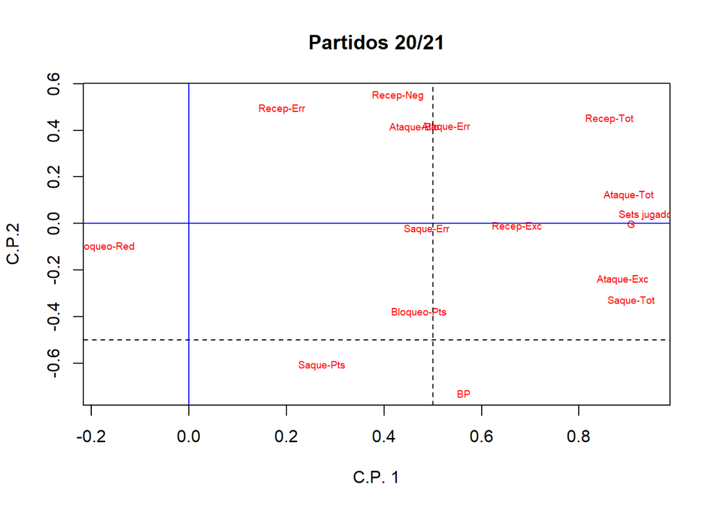

```r
#Para ayudar a interpretar las CP:
plot(cor_vc[,1:2],type="n",
     main="Partidos 20/21",
     xlab="C.P. 1",ylab="C.P.2")
text(cor_vc[,1:2],labels=rownames(cor_vc),
     col="red",cex=0.6)
abline(h=0,v=0,lty=1,col="blue")
abline(v=0.5,lty=2)
abline(v=-0.5,lty=2)
abline(h=-0.5,lty=2)
```

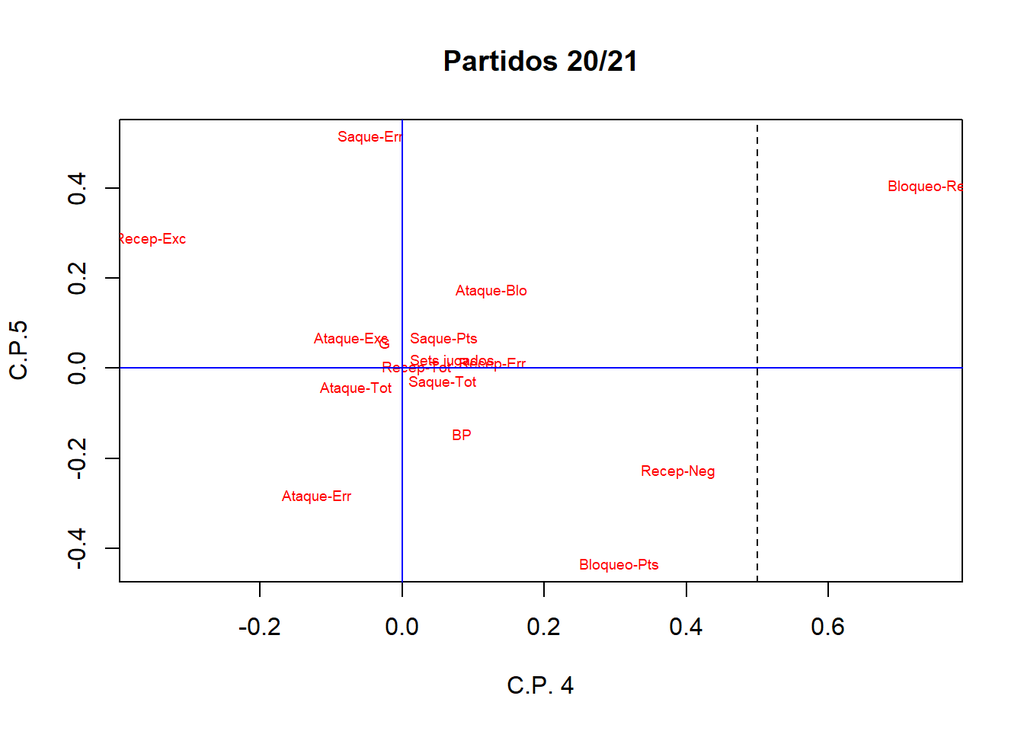

```r
#Para ayudar a interpretar las CP:
plot(cor_vc[,4:5],type="n",
     main="Partidos 20/21",
     xlab="C.P. 4",ylab="C.P.5")
text(cor_vc[,4:5],labels=rownames(cor_vc),
     col="red",cex=0.6)
abline(h=0,v=0,lty=1,col="blue")
abline(v=0.5,lty=2)
abline(v=-0.5,lty=2)
abline(h=-0.5,lty=2)
```

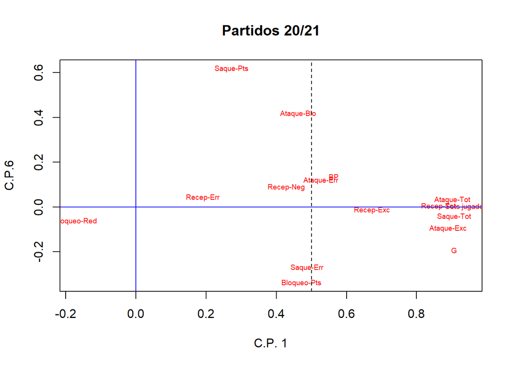

```r
#Para ayudar a interpretar las CP:
plot(cor_vc[,c(1,6)],type="n",
     main="Partidos 20/21",
     xlab="C.P. 1",ylab="C.P.6")
text(cor_vc[,c(1,6)],labels=rownames(cor_vc),
     col="red",cex=0.6)
abline(h=0,v=0,lty=1,col="blue")
abline(v=0.5,lty=2)
abline(v=-0.5,lty=2)
abline(h=-0.5,lty=2)
```

No se pueden interpretar bien las componentes principales, luego no nos son útiles para el estudio.

## Modelos estadísticos (con las variables seleccionadas)

### Partición entrenamiento/test

```r
n<- nrow(dat)
indin<- 1:n
nent<-ceiling(0.7*n)
ntest<- n-nent
set.seed(2468)
indient<- sort(sample(indin,nent))
inditest<- setdiff(indin,indient)
datent<- dat[indient,]
dattest<- dat[inditest,]

head(dattest,10)
```

```
## # A tibble: 10 x 18
##    Equipo         `Sets jugados`    BP     G `Saque-Tot` `Saque-Pts` `Saque-Err`
##    <chr>                   <dbl> <dbl> <dbl>       <dbl>       <dbl>       <dbl>
##  1 Cajasol Juvasa              3    15    33          62           2          10
##  2 AD Algar Surm~              5    31    50         107           4           9
##  3 AD Algar Surm~              5    28    40         108           4           8
##  4 AD Algar Surm~              4    19    47          96           5           6
##  5 AD Algar Surm~              4    16    40          80           4          15
##  6 AD Algar Surm~              4    26    40          89           7          12
##  7 AD Algar Surm~              4    25    36          86           2          10
##  8 AD Algar Surm~              3     9    26          56           4           4
##  9 Arenal Emevé                3    14    26          67           3           9
## 10 Arenal Emevé                5    29    55         101           6           9
## # ... with 11 more variables: Recep-Tot <dbl>, Recep-Err <dbl>,
## #   Recep-Neg <dbl>, Recep-Exc <dbl>, Ataque-Tot <dbl>, Ataque-Err <dbl>,
## #   Ataque-Blo <dbl>, Ataque-Exc <dbl>, Bloqueo-Red <dbl>, Bloqueo-Pts <dbl>,
## #   Ganado/Perdido <fct>
```

### Regla simple de Bayes

```r
library(e1071)
modeloNB<- naiveBayes(`Ganado/Perdido` ~ ., data = datent[,2:18])
modeloNB       # para cada variable, Media [,1] y s.d [,2] en cada categoria de la variable objetivo
```

```
##
## Naive Bayes Classifier for Discrete Predictors
##
## Call:
## naiveBayes.default(x = X, y = Y, laplace = laplace)
##
## A-priori probabilities:
## Y
##         0         1
## 0.4972973 0.5027027
##
## Conditional probabilities:
##    Sets jugados
## Y       [,1]      [,2]
##   0 3.782609 0.7959525
##   1 3.795699 0.8413129
##
##    BP
## Y       [,1]     [,2]
##   0 19.45652 7.319120
##   1 30.03226 5.057177
##
##    G
## Y       [,1]     [,2]
##   0 34.11957 9.402878
##   1 35.97849 9.323857
##
##    Saque-Tot
## Y       [,1]     [,2]
##   0 75.55435 19.39489
##   1 88.76344 15.00246
##
##    Saque-Pts
## Y       [,1]     [,2]
##   0 3.782609 2.479924
##   1 5.752688 2.958613
##
##    Saque-Err
## Y       [,1]     [,2]
##   0 9.076087 3.641138
```

[output cut: 36 more lines]

```
##
##    Ataque-Exc
## Y       [,1]     [,2]
##   0 41.78261 11.99526
##   1 50.22581 10.23541
##
##    Bloqueo-Red
## Y         [,1]      [,2]
##   0 0.02173913 0.2085144
##   1 0.02150538 0.1458479
##
##    Bloqueo-Pts
## Y       [,1]     [,2]
##   0  8.01087 3.242894
##   1 10.03226 3.971232
```

```r
preditestNB<- predict(modeloNB,dattest)
confutestNB<-table(dattest$`Ganado/Perdido`,preditestNB)
confutestNB
```

```
##    preditestNB
##      0  1
##   0 35  6
##   1  6 32
```

```r
AciertoNB=round(100*mean(dattest$`Ganado/Perdido`==preditestNB),2)
SensEspecNB=round(100*diag(prop.table(confutestNB,1)),2)
c(AciertoNB,SensEspecNB)
```

```
##           0     1
## 84.81 85.37 84.21
```

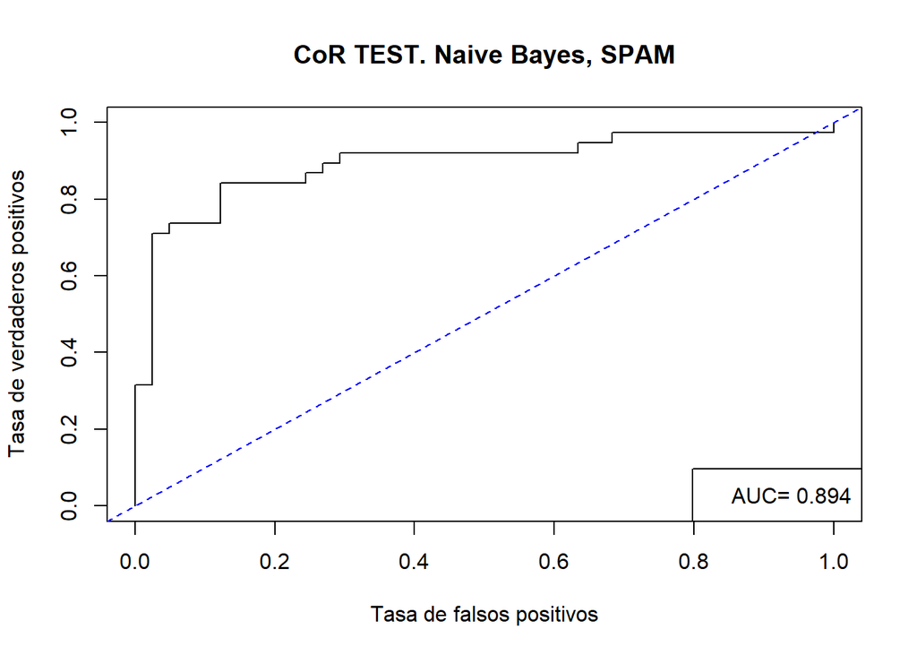

```r
library(ROCR)
probabi1<- predict(modeloNB,dattest,
                   type="raw")[,2] #Prob. ganar partido
prediobj<-prediction(probabi1,dattest$`Ganado/Perdido`)
plot(performance(prediobj, "tpr","fpr"),
     main="CoR TEST. Naive Bayes, SPAM",
     xlab="Tasa de falsos positivos", ylab="Tasa de verdaderos positivos")
abline(a=0,b=1,col="blue",lty=2)
aucNB<- as.numeric(performance(prediobj,"auc")@y.values)
legend("bottomright",legend=paste("AUC=",round(aucNB,3)))
```

Guardamos resultados

```r
Resul=c(Acierto=AciertoNB,AUC=aucNB,SensEspecNB)
Resul
```

```
##   Acierto       AUC         0         1
## 84.810000  0.894095 85.370000 84.210000
```

#### Otra libreria

```r
detach("package:e1071")
library(naivebayes)
modeloNB2<- naive_bayes(`Ganado/Perdido` ~ ., data = datent[,2:18],
                        usekernel=TRUE,kernel ="epanechnikov",bw="nrd0",
                        usepoisson=T)
# podemos hacerlo por equipos
# modeloNB2<- naive_bayes(`Ganado/Perdido` ~ ., data = datent,
#                         usekernel=TRUE,kernel ="epanechnikov",bw="nrd0",
#                         usepoisson=T)

#usekernel=TRUE permite estimar la funcion de densidad
#mediante el metodo nucleo para variables numericas
#utilizando la funcion density, por defecto nucleo gaussiano
#y metodo nrd0 para estimar amplitud de ventana
#usepoisson=TRUE permite estimar la funcion de probabilidad
#mediante el ajuste de una ley Poisson para variables "integer"
#por defecto estimadores maxima verosimilitud ver help(naive_bayes)
#y el documento intro_naivebayes.pdf

summary(modeloNB2)
```

```
##
## ================================== Naive Bayes ==================================
##
## - Call: naive_bayes.formula(formula = `Ganado/Perdido` ~ ., data = datent[,      2:18], usekernel = TRUE, usepoisson = T, kernel = "epanechnikov",      bw = "nrd0")
## - Laplace: 0
## - Classes: 2
## - Samples: 185
## - Features: 16
## - Conditional distributions:
##     - KDE: 16
## - Prior probabilities:
##     - 0: 0.4973
##     - 1: 0.5027
##
## ---------------------------------------------------------------------------------
```

```r
modeloNB2
```

```
##
## ================================== Naive Bayes ==================================
##
##  Call:
## naive_bayes.formula(formula = `Ganado/Perdido` ~ ., data = datent[,
##     2:18], usekernel = TRUE, usepoisson = T, kernel = "epanechnikov",
##     bw = "nrd0")
##
## ---------------------------------------------------------------------------------
##
## Laplace smoothing: 0
##
## ---------------------------------------------------------------------------------
##
##  A priori probabilities:
##
##         0         1
## 0.4972973 0.5027027
##
## ---------------------------------------------------------------------------------
##
##  Tables:
##
## ---------------------------------------------------------------------------------
##  ::: Sets jugados::0 (KDE)
## ---------------------------------------------------------------------------------
##
## Call:
##  density.default(x = x, bw = "nrd0", kernel = "epanechnikov",     na.rm = TRUE)
##
## Data: x (92 obs.);   Bandwidth 'bw' = 0.2719
##
##        x               y
##  Min.   :2.184   Min.   :0.0000
##  1st Qu.:3.092   1st Qu.:0.1948
##  Median :4.000   Median :0.2773
##  Mean   :4.000   Mean   :0.2751
##  3rd Qu.:4.908   3rd Qu.:0.3855
##  Max.   :5.816   Max.   :0.5497
##
```

[output cut: 143 more lines]

```
## Data: x (93 obs.);   Bandwidth 'bw' = 0.8139
##
##        x                y
##  Min.   :-2.442   Min.   :0.00000
##  1st Qu.: 2.029   1st Qu.:0.01717
##  Median : 6.500   Median :0.03767
##  Mean   : 6.500   Mean   :0.05586
##  3rd Qu.:10.971   3rd Qu.:0.09014
##  Max.   :15.442   Max.   :0.16595
##
## ---------------------------------------------------------------------------------
##
## # ... and 11 more tables
##
## ---------------------------------------------------------------------------------
```

```r
#Evaluar el rendimiento
preditestNB2<- predict(modeloNB2,dattest[,2:17])
confutestNB2<-table(dattest$`Ganado/Perdido`,preditestNB2)
confutestNB2
```

```
##    preditestNB2
##      0  1
##   0 32  9
##   1  6 32
```

```r
AciertoNB2=round(100*mean(dattest$`Ganado/Perdido`==preditestNB2),2)
SensEspecNB2=round(100*diag(prop.table(confutestNB2,1)),2)
c(AciertoNB2, SensEspecNB2)
```

```
##           0     1
## 81.01 78.05 84.21
```

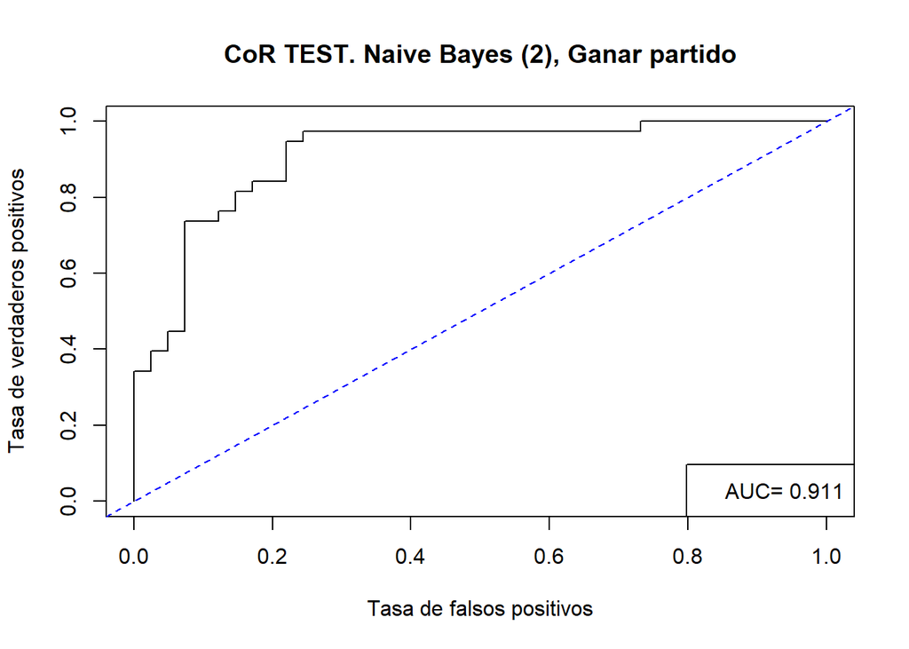

```r
probabi2<- predict(modeloNB2,dattest[,2:17],
                   type="prob")[,2] #Prob. ganado
prediobj2<-prediction(probabi2,dattest$`Ganado/Perdido`)
plot(performance(prediobj2, "tpr","fpr"),
     main="CoR TEST. Naive Bayes (2), Ganar partido",
     xlab="Tasa de falsos positivos", ylab="Tasa de verdaderos positivos")
abline(a=0,b=1,col="blue",lty=2)
aucNB2<- as.numeric(performance(prediobj2,"auc")@y.values)
legend("bottomright",legend=paste("AUC=",round(aucNB2,3)))
```

```r
Resul=rbind(Resul,c(AciertoNB2,aucNB2,SensEspecNB2))
rownames(Resul)=c("Gauss","Kernel(Poisson)")
Resul
```

```
##                 Acierto       AUC     0     1
## Gauss             84.81 0.8940950 85.37 84.21
## Kernel(Poisson)   81.01 0.9107831 78.05 84.21
```

### Análisis discriminante lineal

```r
library(MASS)
modeloLDA = lda(`Ganado/Perdido` ~. , datent[,2:18])
modeloLDA
```

```
## Call:
## lda(`Ganado/Perdido` ~ ., data = datent[, 2:18])
##
## Prior probabilities of groups:
##         0         1
## 0.4972973 0.5027027
##
## Group means:
##   `Sets jugados`       BP        G `Saque-Tot` `Saque-Pts` `Saque-Err`
## 0       3.782609 19.45652 34.11957    75.55435    3.782609    9.076087
## 1       3.795699 30.03226 35.97849    88.76344    5.752688    8.752688
##   `Recep-Tot` `Recep-Err` `Recep-Neg` `Recep-Exc` `Ataque-Tot` `Ataque-Err`
## 0    79.77174    5.619565    23.90217    29.67391     129.4348     12.50000
## 1    66.79570    3.537634    17.52688    28.51613     127.2581     10.04301
##   `Ataque-Blo` `Ataque-Exc` `Bloqueo-Red` `Bloqueo-Pts`
## 0    10.217391     41.78261    0.02173913       8.01087
## 1     7.677419     50.22581    0.02150538      10.03226
##
## Coefficients of linear discriminants:
##                         LD1
## `Sets jugados` -0.165283206
## BP              0.056292867
## G               0.054135326
## `Saque-Tot`     0.052078083
## `Saque-Pts`    -0.039623741
## `Saque-Err`    -0.038740936
## `Recep-Tot`    -0.122976427
## `Recep-Err`     0.034456888
## `Recep-Neg`     0.013940734
## `Recep-Exc`     0.001495282
## `Ataque-Tot`   -0.001017513
## `Ataque-Err`    0.011787154
## `Ataque-Blo`   -0.034964195
## `Ataque-Exc`    0.058993188
## `Bloqueo-Red`   0.550241207
## `Bloqueo-Pts`  -0.004794856
```

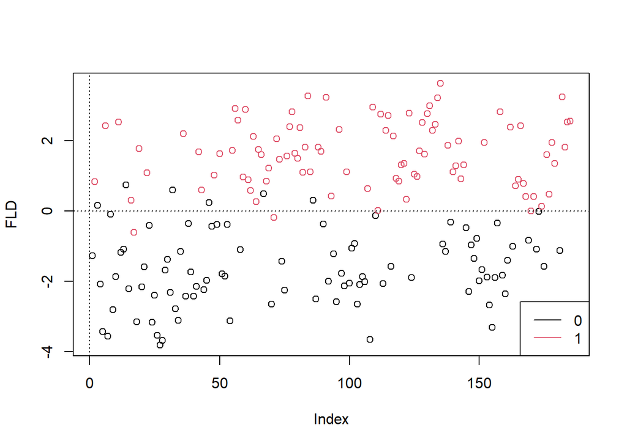

```r
#Coeficientes FLD en cada caso:
FLD=predict(modeloLDA)$x
plot(FLD, col = datent[,18]$`Ganado/Perdido`)
abline(h=0,v=0,lty=3)
legend("bottomright",col=1:2,lty=1,
       legend=levels(datent$`Ganado/Perdido`))
```

```r
preditestLDA=predict(modeloLDA,newdata=dattest[,2:18])$class
confutestLDA=table(Real=dat[inditest,18]$`Ganado/Perdido`,Predic=preditestLDA)
confutestLDA
```

```
##     Predic
## Real  0  1
##    0 36  5
##    1  4 34
```

```r
AciertoLDA=round(100*mean(dattest$`Ganado/Perdido`==preditestLDA),2)
SensEspecLDA=round(100*diag(prop.table(confutestLDA,1)),2)
c(AciertoLDA, SensEspecLDA)
```

```
##           0     1
## 88.61 87.80 89.47
```

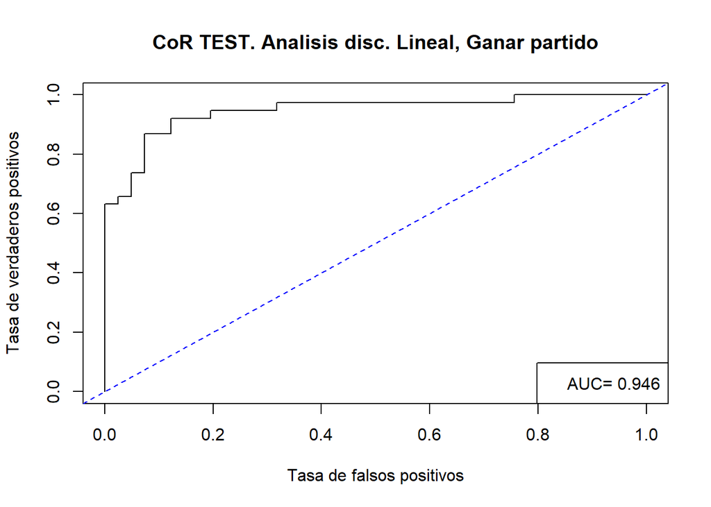

```r
probabiLDA<- predict(modeloLDA,dattest[,2:17],
                   type="prob")$posterior[,2] #Prob. ganado
prediobjLDA<-prediction(probabiLDA,dattest$`Ganado/Perdido`)
plot(performance(prediobjLDA, "tpr","fpr"),
     main="CoR TEST. Analisis disc. Lineal, Ganar partido",
     xlab="Tasa de falsos positivos", ylab="Tasa de verdaderos positivos")
abline(a=0,b=1,col="blue",lty=2)
aucLDA<- as.numeric(performance(prediobjLDA,"auc")@y.values)
legend("bottomright",legend=paste("AUC=",round(aucLDA,3)))
```

```r
Resul=rbind(Resul,c(AciertoLDA,aucLDA,SensEspecLDA))
rownames(Resul)=c("Gauss","Kernel(Poisson)","LDA")
Resul
```

```
##                 Acierto       AUC     0     1
## Gauss             84.81 0.8940950 85.37 84.21
## Kernel(Poisson)   81.01 0.9107831 78.05 84.21
## LDA               88.61 0.9460847 87.80 89.47
```

### Regresión Logística

```r
modeloRL<- glm(`Ganado/Perdido`~.,family=binomial,data=datent[,2:18])
summary(modeloRL)
```

```
##
## Call:
## glm(formula = `Ganado/Perdido` ~ ., family = binomial, data = datent[,
##     2:18])
##
## Deviance Residuals:
##      Min        1Q    Median        3Q       Max
## -1.98108  -0.01116   0.00075   0.05491   2.78686
##
## Coefficients: (1 not defined because of singularities)
##                 Estimate Std. Error z value Pr(>|z|)
## (Intercept)    -5.122602   4.580465  -1.118  0.26341
## `Sets jugados` -0.648016   2.230774  -0.290  0.77144
## BP              0.146225   0.172401   0.848  0.39634
## G               0.132572   0.240044   0.552  0.58075
## `Saque-Tot`     0.335767   0.160750   2.089  0.03673 *
## `Saque-Pts`    -0.120591   0.202100  -0.597  0.55072
## `Saque-Err`    -0.091613   0.151841  -0.603  0.54628
## `Recep-Tot`    -0.515526   0.198638  -2.595  0.00945 **
## `Recep-Err`    -0.106450   0.233017  -0.457  0.64779
## `Recep-Neg`     0.103785   0.106481   0.975  0.32972
## `Recep-Exc`     0.013582   0.067740   0.201  0.84109
## `Ataque-Tot`    0.004566   0.037070   0.123  0.90198
## `Ataque-Err`   -0.068466   0.175064  -0.391  0.69573
## `Ataque-Blo`   -0.314011   0.217515  -1.444  0.14884
## `Ataque-Exc`    0.228187   0.169631   1.345  0.17856
## `Bloqueo-Red`   4.328331  23.113715   0.187  0.85145
## `Bloqueo-Pts`         NA         NA      NA       NA
## ---
## Signif. codes:  0 '***' 0.001 '**' 0.01 '*' 0.05 '.' 0.1 ' ' 1
##
## (Dispersion parameter for binomial family taken to be 1)
##
##     Null deviance: 256.459  on 184  degrees of freedom
## Residual deviance:  39.722  on 169  degrees of freedom
## AIC: 71.722
##
## Number of Fisher Scoring iterations: 9
```

```r
# Vamos a ver si el modelo nos sirve para ajustar estos datos
library(generalhoslem)
prob=fitted(modeloRL)   #probabilidades estimadas por el modelo
HS=logitgof(datent$`Ganado/Perdido`, prob,g=10)
#Nos queda un p-valor de 0.5358, luego podemos concluir que el modelo proporciona un buen ajuste.
```

Modelo con las variables `Saque-Tot` y `Recep-Tot`

```r
modeloRL1<- glm(`Ganado/Perdido`~.,family=binomial,data=datent[c("Saque-Tot","Recep-Tot","Ganado/Perdido")])
summary(modeloRL1)
```

```
##
## Call:
## glm(formula = `Ganado/Perdido` ~ ., family = binomial, data = datent[c("Saque-Tot",
##     "Recep-Tot", "Ganado/Perdido")])
##
## Deviance Residuals:
##      Min        1Q    Median        3Q       Max
## -2.34015  -0.07643   0.00665   0.14805   1.79687
##
## Coefficients:
##             Estimate Std. Error z value Pr(>|z|)
## (Intercept) -3.54069    2.34929  -1.507    0.132
## `Saque-Tot`  0.38409    0.07376   5.207 1.91e-07 ***
## `Recep-Tot` -0.38966    0.07092  -5.494 3.92e-08 ***
## ---
## Signif. codes:  0 '***' 0.001 '**' 0.01 '*' 0.05 '.' 0.1 ' ' 1
##
## (Dispersion parameter for binomial family taken to be 1)
##
##     Null deviance: 256.459  on 184  degrees of freedom
## Residual deviance:  60.297  on 182  degrees of freedom
## AIC: 66.297
##
## Number of Fisher Scoring iterations: 8
```

```r
modeloRL1
```

```
##
## Call:  glm(formula = `Ganado/Perdido` ~ ., family = binomial, data = datent[c("Saque-Tot",
##     "Recep-Tot", "Ganado/Perdido")])
##
## Coefficients:
## (Intercept)  `Saque-Tot`  `Recep-Tot`
##     -3.5407       0.3841      -0.3897
##
## Degrees of Freedom: 184 Total (i.e. Null);  182 Residual
## Null Deviance:       256.5
## Residual Deviance: 60.3  AIC: 66.3
```

**Ganado/Perdido = -3.5407 + Saque-Tot * 0.3841 + Recep-Tot * -0.3897**

```r
preditestRL=as.numeric(predict(modeloRL1,dat[inditest,], type="response")>0.5)
confutestRL<-table(Real=dat[inditest,18]$`Ganado/Perdido`,Predic=preditestRL)
confutestRL
```

```
##     Predic
## Real  0  1
##    0 37  4
##    1  6 32
```

```r
AciertoRL=round(100*mean(as.numeric(dattest$`Ganado/Perdido`)==(preditestRL+1)),2)
SensEspecRL=round(100*diag(prop.table(confutestRL,1)),2)
c(AciertoRL, SensEspecRL)
```

```
##           0     1
## 87.34 90.24 84.21
```

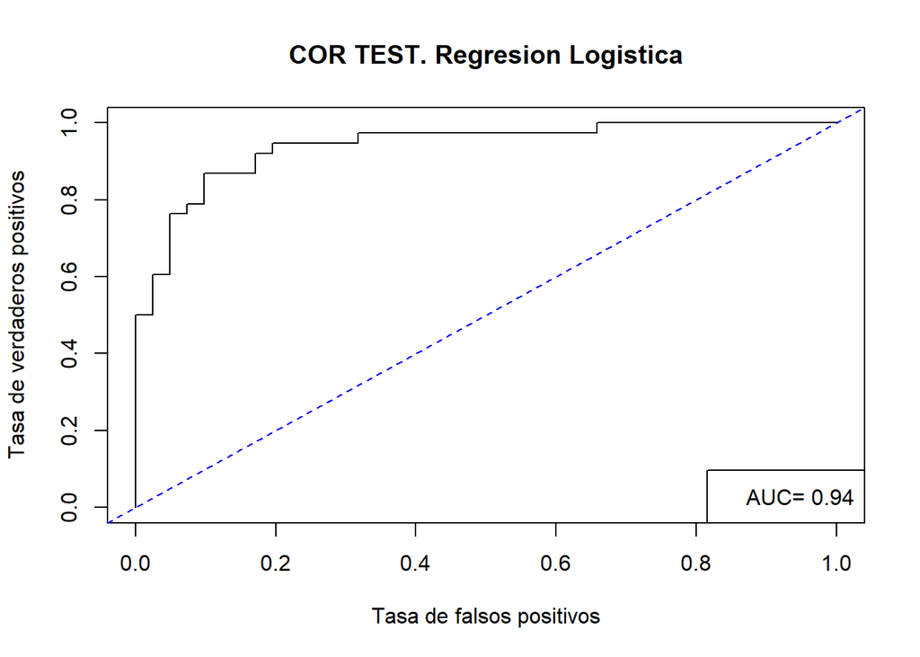

```r
probabiRL<- predict(modeloRL1,dat[inditest,],type="response") #Prob. 1
prediobjRL<-prediction(probabiRL,dat[inditest,18])
plot(performance(prediobjRL, "tpr","fpr"),
     main="COR TEST. Regresion Logistica",
     xlab="Tasa de falsos positivos",
     ylab="Tasa de verdaderos positivos")
abline(a=0,b=1,col="blue",lty=2)
aucRL<- as.numeric(performance(prediobjRL,"auc")@y.values)
legend("bottomright",legend=paste("AUC=",round(aucRL,3)))
```

```r
Resul=rbind(Resul,c(AciertoRL,aucRL,SensEspecRL))
rownames(Resul)=c("Gauss","Kernel(Poisson)","LDA","R.Logistica")
Resul
```

```
##                 Acierto       AUC     0     1
## Gauss             84.81 0.8940950 85.37 84.21
## Kernel(Poisson)   81.01 0.9107831 78.05 84.21
## LDA               88.61 0.9460847 87.80 89.47
## R.Logistica       87.34 0.9403081 90.24 84.21
```

```r
levels(dat$`Ganado/Perdido`)=c("Perdido","Ganado")
levels(dattest$`Ganado/Perdido`)=c("Perdido","Ganado")
levels(datent$`Ganado/Perdido`)=c("Perdido","Ganado")
```

### Redes Neuronales

```r
library(NeuralNetTools) #para representar graficamente
library(caret)
ctrlRD <- trainControl(method="cv",classProbs = T,
                     summaryFunction = twoClassSummary, verboseIter = F)

modeloPM <- train(`Ganado/Perdido`~ ., data = datent[,-1],
                  method = "nnet",
                  trControl = ctrlRD,
                  preProcess =c("center","scale"),
     tuneGrid=expand.grid(size=1:18,decay=c(0,0.05,0.1)))
modeloPM
```

```
## Neural Network
##
## 185 samples
##  16 predictor
##   2 classes: 'Perdido', 'Ganado'
##
## Pre-processing: centered (16), scaled (16)
## Resampling: Cross-Validated (10 fold)
## Summary of sample sizes: 166, 165, 167, 167, 167, 166, ...
## Resampling results across tuning parameters:
##
##   size  decay  ROC        Sens       Spec
##    1    0.00   0.9228889  0.9022222  0.9155556
##    1    0.05   0.9701852  0.9133333  0.9366667
##    1    0.10   0.9695432  0.9022222  0.9144444
```

[output cut: 54 more lines]

```r
modeloPM$finalModel
```

```
## a 16-2-1 network with 37 weights
## inputs: `\`Sets jugados\`` BP G `\`Saque-Tot\`` `\`Saque-Pts\`` `\`Saque-Err\`` `\`Recep-Tot\`` `\`Recep-Err\`` `\`Recep-Neg\`` `\`Recep-Exc\`` `\`Ataque-Tot\`` `\`Ataque-Err\`` `\`Ataque-Blo\`` `\`Ataque-Exc\`` `\`Bloqueo-Red\`` `\`Bloqueo-Pts\``
## output(s): .outcome
## options were - entropy fitting  decay=0.1
```

```r
summary(modeloPM)
```

```
## a 16-2-1 network with 37 weights
## options were - entropy fitting  decay=0.1
##   b->h1  i1->h1  i2->h1  i3->h1  i4->h1  i5->h1  i6->h1  i7->h1  i8->h1  i9->h1
##    0.36    0.34    1.98    0.56    1.05    0.03    0.71   -3.05   -0.54   -1.55
## i10->h1 i11->h1 i12->h1 i13->h1 i14->h1 i15->h1 i16->h1
##    0.26   -0.13   -0.75   -1.40    1.87   -0.01   -0.20
##   b->h2  i1->h2  i2->h2  i3->h2  i4->h2  i5->h2  i6->h2  i7->h2  i8->h2  i9->h2
##    0.41    0.34   -1.47   -0.39   -1.21    0.22    0.84    2.73    0.19   -0.93
## i10->h2 i11->h2 i12->h2 i13->h2 i14->h2 i15->h2 i16->h2
##    0.62   -0.73    0.59    0.60   -1.42   -0.15    0.14
##  b->o h1->o h2->o
## -0.59  5.59 -5.26
```

```r
# modeloPM$results
```

```r
preditestPM= predict(modeloPM,dattest[,-18])
confutestPM=table(RealPM_test=dattest[,18]$`Ganado/Perdido`,
                PredPM_test=preditestPM)
kableExtra::kable(confutestPM) %>%
 add_header_above(c("", "Predicción" =2)) %>%
  group_rows("Real", 1, 2)
```

|  | Predicción Perdido | Predicción Ganado |
| --- | --- | --- |
| **Real** |  |  |
| Perdido | 38 | 3 |
| Ganado | 5 | 33 |

```r
AciertoPM=round(100*mean(dattest$`Ganado/Perdido`==preditestPM),2)
SensEspecPM=round(100*diag(prop.table(confutestPM,1)),2)
c(AciertoPM, SensEspecPM)
```

```
##         Perdido  Ganado
##   89.87   92.68   86.84
```

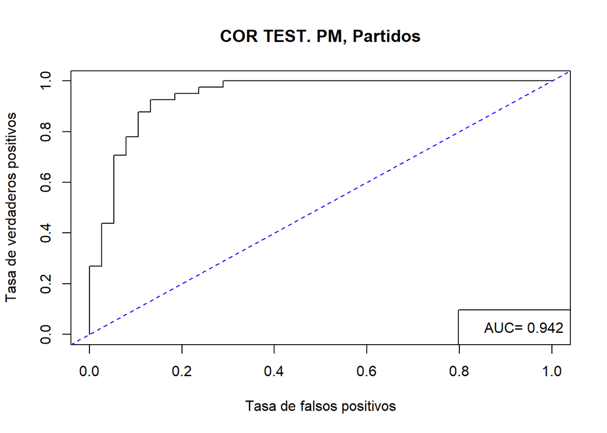

```r
probabiPM= predict(modeloPM,newdata = dat[inditest,2:17] ,
                   type="prob")[,1] #Prob. ganar
prediobjPM=prediction(probabiPM,dat[inditest,18])
plot(performance(prediobjPM, "tpr","fpr"),
     main="COR TEST. PM, Partidos",
     xlab="Tasa de falsos positivos",
     ylab="Tasa de verdaderos positivos")
abline(a=0,b=1,col="blue",lty=2)
aucPM= as.numeric(performance(prediobjPM,"auc")@y.values)
legend("bottomright",legend=paste("AUC=",round(aucPM,3)))
```

```r
Resul=rbind(Resul,c(AciertoPM,aucPM,SensEspecPM))
rownames(Resul)=c("Gauss","Kernel(Poisson)","LDA","R.Logistica","Perceptron Multicapas")
Resul
```

```
##                       Acierto       AUC     0     1
## Gauss                   84.81 0.8940950 85.37 84.21
## Kernel(Poisson)         81.01 0.9107831 78.05 84.21
## LDA                     88.61 0.9460847 87.80 89.47
## R.Logistica             87.34 0.9403081 90.24 84.21
## Perceptron Multicapas   89.87 0.9415918 92.68 86.84
```

#### DIBUJO DE LA RED NEURONAL E IMPORTANCIA DE LAS VARIABLES

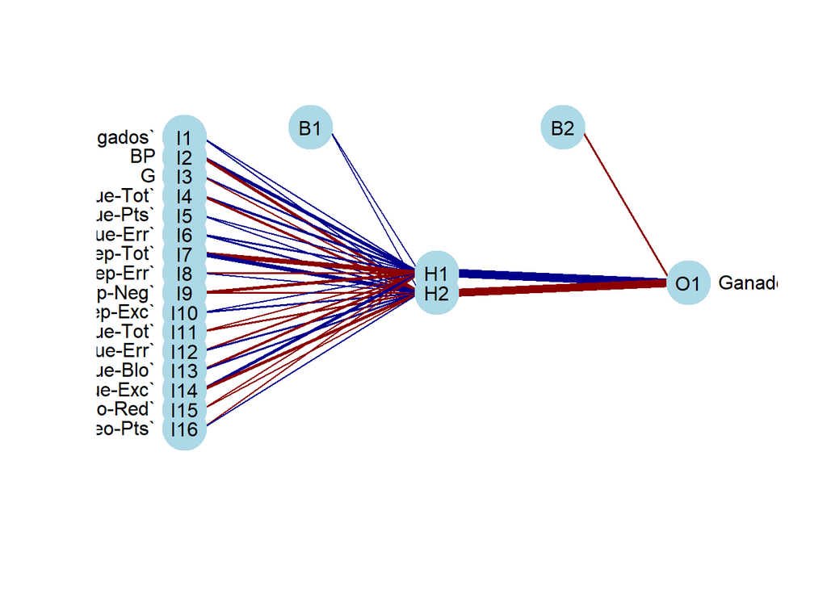

```r
# plotnet(modeloPM)
#negro: valores positivos; gris: negativos
#podemos establecer colores:
plotnet(modeloPM,pos_col='darkblue',neg_col='darkred')
```

```r
neuralweights(modeloPM$finalModel) #coeficientes estimados
```

```
## $struct
## [1] 16  2  1
##
## $wts
## $wts$`hidden 1 1`
##  [1]  0.361127718  0.340643380  1.981557398  0.559964960  1.052058298
##  [6]  0.025932733  0.707852205 -3.053762386 -0.540066157 -1.546034424
## [11]  0.262791059 -0.128014732 -0.753608212 -1.401288025  1.867797848
## [16] -0.008065706 -0.204279115
##
## $wts$`hidden 1 2`
##  [1]  0.4071747  0.3400835 -1.4729584 -0.3929425 -1.2074584  0.2242812
##  [7]  0.8447302  2.7335300  0.1940559 -0.9304950  0.6196767 -0.7262122
## [13]  0.5949369  0.6010771 -1.4247345 -0.1482132  0.1375576
##
## $wts$`out 1`
## [1] -0.5933753  5.5881162 -5.2552220
```

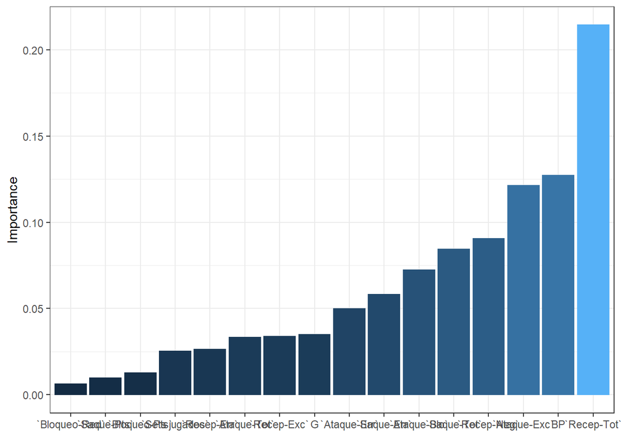

```r
garson(modeloPM) #Importancia relativa de las variables de entrada en redes
```

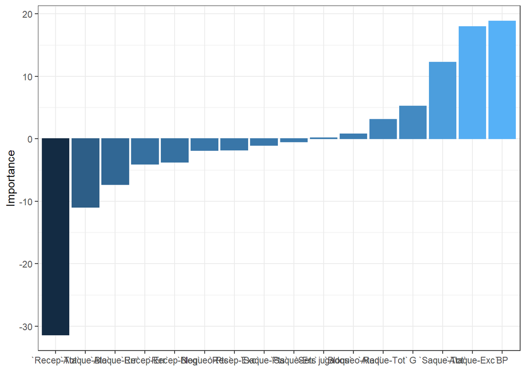

```r
# neuronales utilizando el algoritmo de Garson
olden(modeloPM) # Importancia relativa de las variables de entrada en las
```

```r
# redes neuronales como la suma del producto de los pesos de conexion de
# entrada oculta, salida oculta, propuesta por Olden et al. 2004.
# help(garson)
# help(olden)
garson(modeloPM,bar_plot=FALSE) #estimaciones sin dibujar
```

```
##                    rel_imp
## `Sets jugados` 0.025303203
## BP             0.127126838
## G              0.034999503
## `Saque-Tot`    0.084386338
## `Saque-Pts`    0.009803372
## `Saque-Err`    0.058060612
## `Recep-Tot`    0.214319925
## `Recep-Err`    0.026413437
## `Recep-Neg`    0.090501447
## `Recep-Exc`    0.033707498
## `Ataque-Tot`   0.033268667
## `Ataque-Err`   0.049727662
## `Ataque-Blo`   0.072407807
## `Ataque-Exc`   0.121271362
## `Bloqueo-Red`  0.006164176
## `Bloqueo-Pts`  0.012538151
```

```r
#suman 1
sum(garson(modeloPM,bar_plot=FALSE))
```

```
## [1] 1
```

### Vectores soporte

Vamos a ver si la muestra está balanceada

```r
table(datent$`Ganado/Perdido`) # datos no balanceados
```

```
##
## Perdido  Ganado
##      92      93
```

Vamos a hacerlo con la librería caret.

```r
#Definir opciones para train
ctrl <- trainControl(method="cv",classProbs=TRUE,
                     summaryFunction = twoClassSummary)

modeloSVM <- train(`Ganado/Perdido` ~ ., data = datent[,2:18],
                   method = "svmRadial",
                   trControl = ctrl,
                   preProcess = "range",
                   rangeBounds  =c(0,1),
                   tuneGrid = expand.grid(C=c(0.1,1,5,10,50),
                                          sigma=c(0.025,0.035,0.5)) )
modeloSVM
```

```
## Support Vector Machines with Radial Basis Function Kernel
##
## 185 samples
##  16 predictor
##   2 classes: 'Perdido', 'Ganado'
##
## Pre-processing: re-scaling to [0, 1] (16)
## Resampling: Cross-Validated (10 fold)
## Summary of sample sizes: 166, 167, 167, 165, 166, 167, ...
## Resampling results across tuning parameters:
##
##   C     sigma  ROC        Sens       Spec
##    0.1  0.025  0.9680247  0.8477778  0.9566667
##    0.1  0.035  0.9655556  0.8366667  0.9344444
##    0.1  0.500  0.9380247  0.3111111  0.8522222
##    1.0  0.025  0.9694938  0.8811111  0.9155556
##    1.0  0.035  0.9646790  0.8811111  0.8833333
##    1.0  0.500  0.9311111  0.9133333  0.8288889
##    5.0  0.025  0.9639259  0.8822222  0.8722222
##    5.0  0.035  0.9555432  0.8600000  0.8722222
##    5.0  0.500  0.9265432  0.8800000  0.8188889
##   10.0  0.025  0.9577654  0.8700000  0.8944444
##   10.0  0.035  0.9413333  0.8688889  0.8944444
##   10.0  0.500  0.9265432  0.8688889  0.8300000
##   50.0  0.025  0.9270123  0.8788889  0.8844444
##   50.0  0.035  0.9328272  0.8566667  0.8833333
##   50.0  0.500  0.9265432  0.8911111  0.8300000
##
## ROC was used to select the optimal model using the largest value.
## The final values used for the model were sigma = 0.025 and C = 1.
```

```r
predictestSVM<- predict(modeloSVM,dattest[,2:17])
confutestSVM<-table(Real=dattest$`Ganado/Perdido`,
                 Predicción=predictestSVM)
confutestSVM
```

```
##          Predicción
## Real      Perdido Ganado
##   Perdido      38      3
##   Ganado        7     31
```

```r
AciertoSVM=round(100*mean(dattest$`Ganado/Perdido`==predictestSVM),2)
SensEspecSVM=round(100*diag(prop.table(confutestSVM,1)),2)
c(AciertoSVM, SensEspecSVM)
```

```
##         Perdido  Ganado
##   87.34   92.68   81.58
```

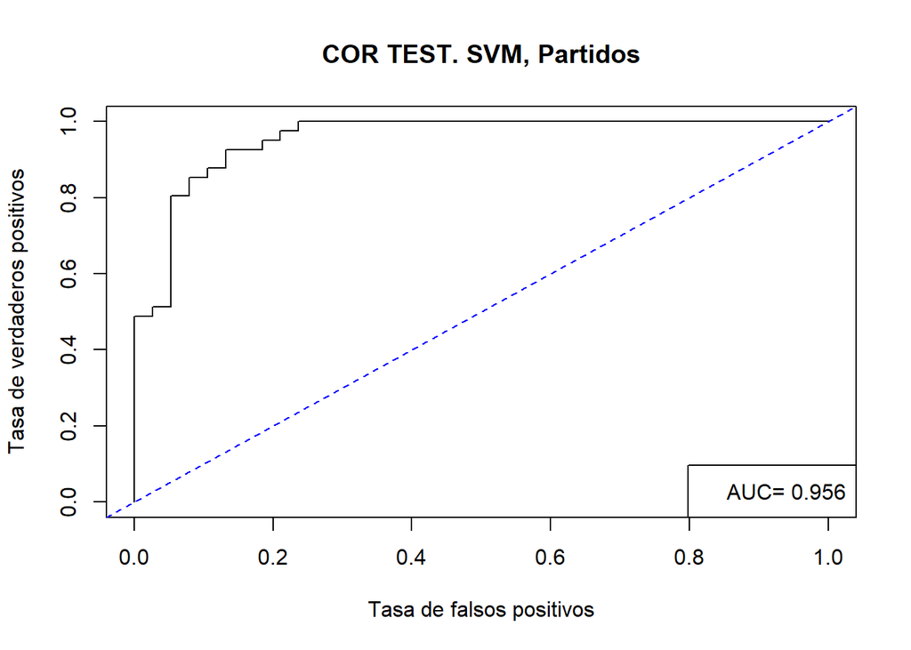

```r
probabiSVM= predict(modeloSVM,newdata = dat[inditest,2:17] ,
                   type="prob")[,1] #Prob. ganar
prediobjSVM=prediction(probabiSVM,dat[inditest,18])
plot(performance(prediobjSVM, "tpr","fpr"),
     main="COR TEST. SVM, Partidos",
     xlab="Tasa de falsos positivos",
     ylab="Tasa de verdaderos positivos")
abline(a=0,b=1,col="blue",lty=2)
aucSVM= as.numeric(performance(prediobjSVM,"auc")@y.values)
legend("bottomright",legend=paste("AUC=",round(aucSVM,3)))
```

```r
Resul=rbind(Resul,c(AciertoSVM,aucSVM,SensEspecSVM))
rownames(Resul)=c("Gauss","Kernel(Poisson)","LDA","R.Logistica","Perceptron Multicapas", "Vectores soporte")
Resul
```

```
##                       Acierto       AUC     0     1
## Gauss                   84.81 0.8940950 85.37 84.21
## Kernel(Poisson)         81.01 0.9107831 78.05 84.21
## LDA                     88.61 0.9460847 87.80 89.47
## R.Logistica             87.34 0.9403081 90.24 84.21
## Perceptron Multicapas   89.87 0.9415918 92.68 86.84
## Vectores soporte        87.34 0.9557125 92.68 81.58
```

Dibujar las clases

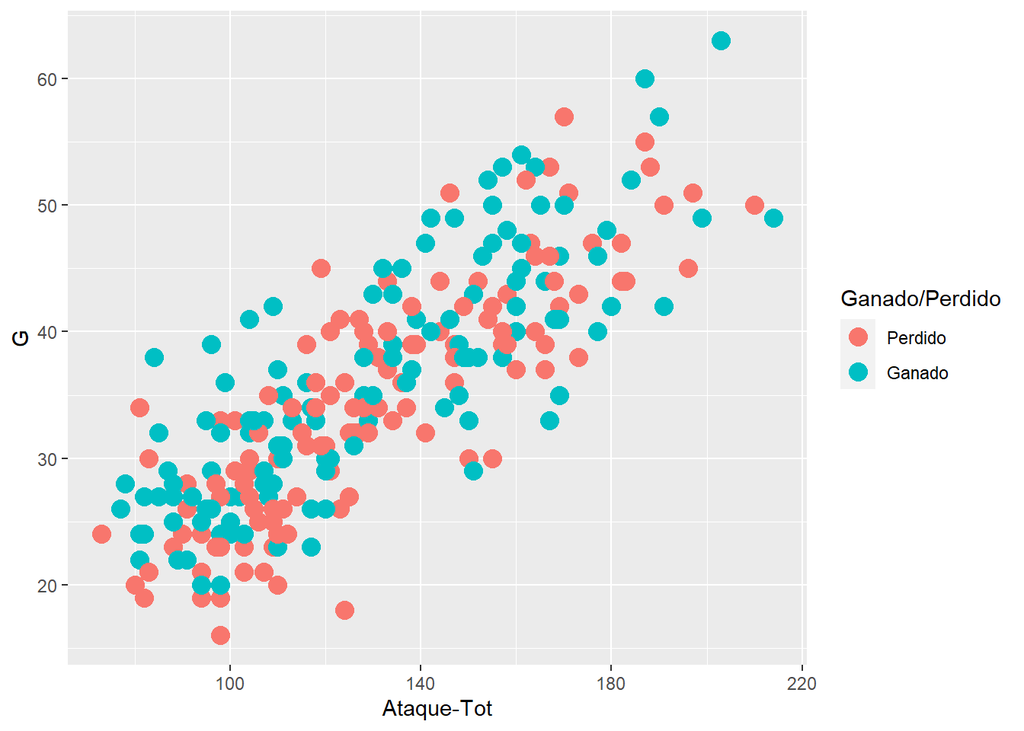

```r
ggplot() +
  geom_point(data = dat, aes(x = `Ataque-Tot`, y = G, color = `Ganado/Perdido`), size = 4)
```

Vamos a utilizar la técnica UPSAMPLE: se muestrea con reemplazamiento en la clase minoritaria para igualar el número de casos de la clase mayoritaria. Comparamos los dos modelos puesto que las muestras no son balanceadas por un registro.

```r
upSampled_train = upSample(datent[, 2:17],
                           datent$`Ganado/Perdido`)
dim(upSampled_train)
```

```
## [1] 186  17
```

```r
table(upSampled_train$Class)
```

```
##
## Perdido  Ganado
##      93      93
```

```r
names(upSampled_train)[17]= "Ganado/Perdido"
```

```r
ctrl5 = trainControl(method = "cv",
                     number=5,
                    classProbs = TRUE,
                    summaryFunction = twoClassSummary)

SVMUp=train(`Ganado/Perdido` ~ .,
            data = upSampled_train,
            method = "svmRadial",
            preProcess = "range",
            rangeBounds =c(0,1),
            tuneLength=10,
            trControl = ctrl5,
            tuneGrid = expand.grid(C=c(0.1,1,5,10,50),
                                          sigma=c(0.025,0.035,0.05)),
            metric="Sens")
SVMUp
```

```
## Support Vector Machines with Radial Basis Function Kernel
##
## 186 samples
##  16 predictor
##   2 classes: 'Perdido', 'Ganado'
##
## Pre-processing: re-scaling to [0, 1] (16)
## Resampling: Cross-Validated (5 fold)
## Summary of sample sizes: 148, 148, 148, 150, 150
## Resampling results across tuning parameters:
##
##   C     sigma  ROC        Sens       Spec
##    0.1  0.025  0.9653039  0.8280702  0.9251462
##    0.1  0.035  0.9717144  0.8280702  0.9245614
##    0.1  0.050  0.9668394  0.8280702  0.9035088
##    1.0  0.025  0.9714613  0.8812865  0.9029240
##    1.0  0.035  0.9696095  0.8596491  0.9029240
##    1.0  0.050  0.9702267  0.8608187  0.9029240
##    5.0  0.025  0.9729336  0.9040936  0.8912281
##    5.0  0.035  0.9712082  0.8929825  0.8912281
##    5.0  0.050  0.9663332  0.8929825  0.8807018
##   10.0  0.025  0.9741681  0.8929825  0.8912281
##   10.0  0.035  0.9676311  0.9040936  0.8801170
##   10.0  0.050  0.9580709  0.8608187  0.8590643
##   50.0  0.025  0.9590045  0.8508772  0.8807018
##   50.0  0.035  0.9508054  0.8502924  0.8807018
##   50.0  0.050  0.9426063  0.8608187  0.8590643
##
## Sens was used to select the optimal model using the largest value.
## The final values used for the model were sigma = 0.025 and C = 5.
```

Evaluamos el modelo

```r
predictestUp = predict(SVMUp, dattest[,2:17])

confutestSVM_up<-table(Real=dattest$`Ganado/Perdido`,
                 Pred=predictestUp)
confutestSVM_up
```

```
##          Pred
## Real      Perdido Ganado
##   Perdido      37      4
##   Ganado        4     34
```

```r
AciertoSVM_up=round(100*mean(dattest$`Ganado/Perdido`==predictestUp),2)
SensEspecSVM_up=round(100*diag(prop.table(confutestSVM_up,1)),2)
c(AciertoSVM_up, SensEspecSVM_up)
```

```
##         Perdido  Ganado
##   89.87   90.24   89.47
```

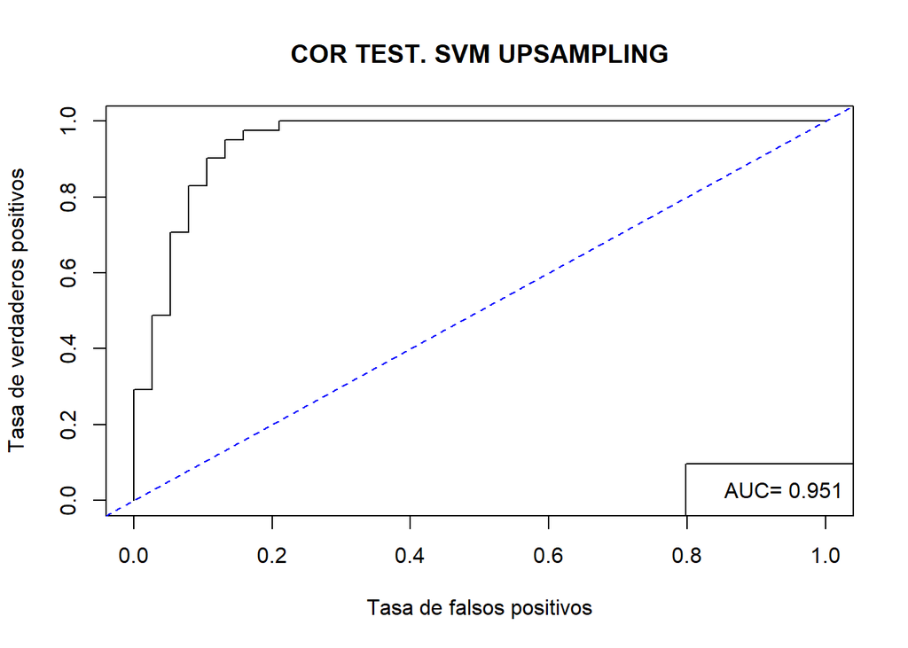

```r
probabiSVM_up= predict(SVMUp,newdata = dat[inditest,2:17] ,
                   type="prob")[,1] #Prob. ganar
prediobjSVM_up = prediction(probabiSVM_up,dat[inditest,18])
plot(performance(prediobjSVM_up, "tpr","fpr"),
     main="COR TEST. SVM UPSAMPLING",
     xlab="Tasa de falsos positivos",
     ylab="Tasa de verdaderos positivos")
abline(a=0,b=1,col="blue",lty=2)
aucSVM_up = as.numeric(performance(prediobjSVM_up,"auc")@y.values)
legend("bottomright",legend=paste("AUC=",round(aucSVM_up,3)))
```

```r
Resul=rbind(Resul,c(AciertoSVM_up,aucSVM_up,SensEspecSVM_up))
rownames(Resul)=c("Gauss","Kernel(Poisson)","LDA","R.Logistica","Perceptron Multicapas", "Vectores soporte","Vectores soporte con Upsampling")
Resul
```

```
##                                 Acierto       AUC     0     1
## Gauss                             84.81 0.8940950 85.37 84.21
## Kernel(Poisson)                   81.01 0.9107831 78.05 84.21
## LDA                               88.61 0.9460847 87.80 89.47
## R.Logistica                       87.34 0.9403081 90.24 84.21
## Perceptron Multicapas             89.87 0.9415918 92.68 86.84
## Vectores soporte                  87.34 0.9557125 92.68 81.58
## Vectores soporte con Upsampling   89.87 0.9505777 90.24 89.47
```

### Árbol de clasificación

```r
library(rpart)
library(graphics)
modeloAB <- rpart(`Ganado/Perdido` ~ .,
                    data=datent[,2:18],method="class")
modeloAB
```

```
## n= 185
##
## node), split, n, loss, yval, (yprob)
##       * denotes terminal node
##
##  1) root 185 92 Ganado (0.49729730 0.50270270)
##    2) BP< 22.5 70  6 Perdido (0.91428571 0.08571429) *
##    3) BP>=22.5 115 28 Ganado (0.24347826 0.75652174)
##      6) Recep-Tot>=80.5 51 25 Perdido (0.50980392 0.49019608)
##       12) Ataque-Exc< 58.5 22  4 Perdido (0.81818182 0.18181818) *
##       13) Ataque-Exc>=58.5 29  8 Ganado (0.27586207 0.72413793) *
##      7) Recep-Tot< 80.5 64  2 Ganado (0.03125000 0.96875000) *
```

```r
# summary(modeloAB)
modeloAB$parms #probabilidades a priori, costes
```

```
## $prior
##         1         2
## 0.4972973 0.5027027
##
## $loss
##      [,1] [,2]
## [1,]    0    1
## [2,]    1    0
##
## $split
## [1] 1
```

```r
modeloAB$variable.importance
```

```
##           BP    Saque-Tot   Ataque-Exc            G    Saque-Pts    Recep-Tot
##    39.160651    33.574644    24.701109    19.053283    16.783136    13.000021
##   Ataque-Tot  Bloqueo-Pts Sets jugados    Recep-Exc
##    12.266372    11.517317    10.339075     7.392169
```

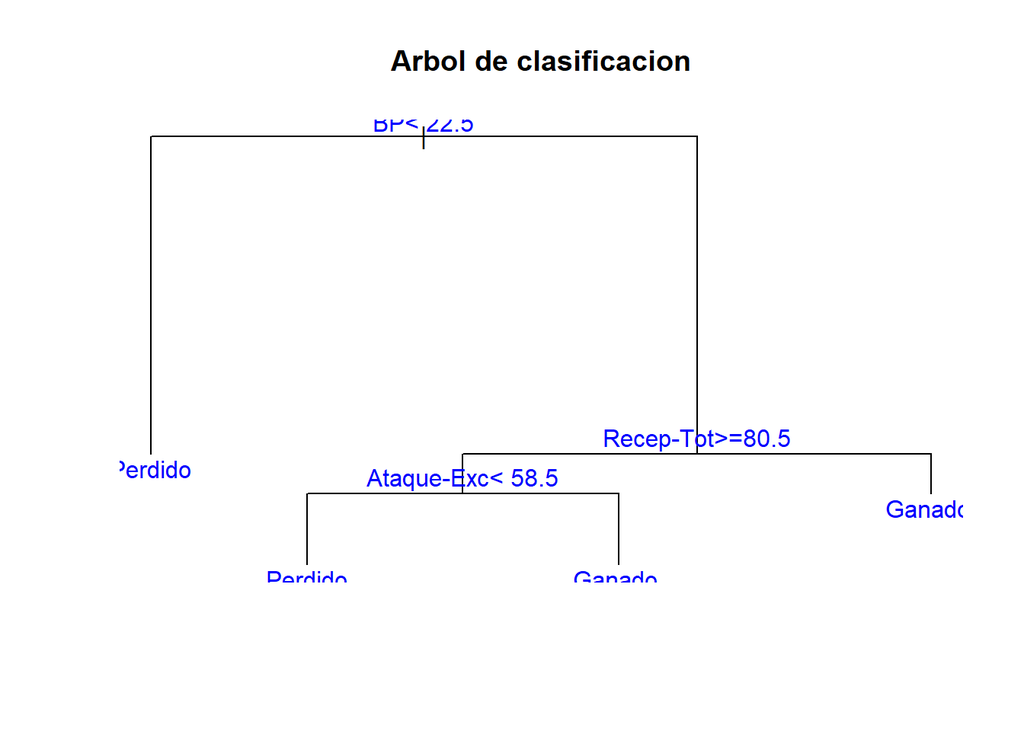

```r
plot(modeloAB,main="Arbol de clasificacion",compress=TRUE)
text(modeloAB,col="blue")
```

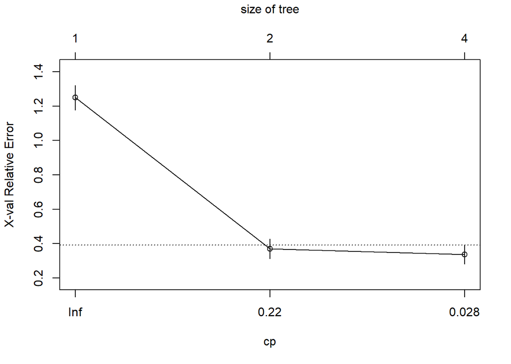

```r
plotcp(modeloAB) # tamaños
```

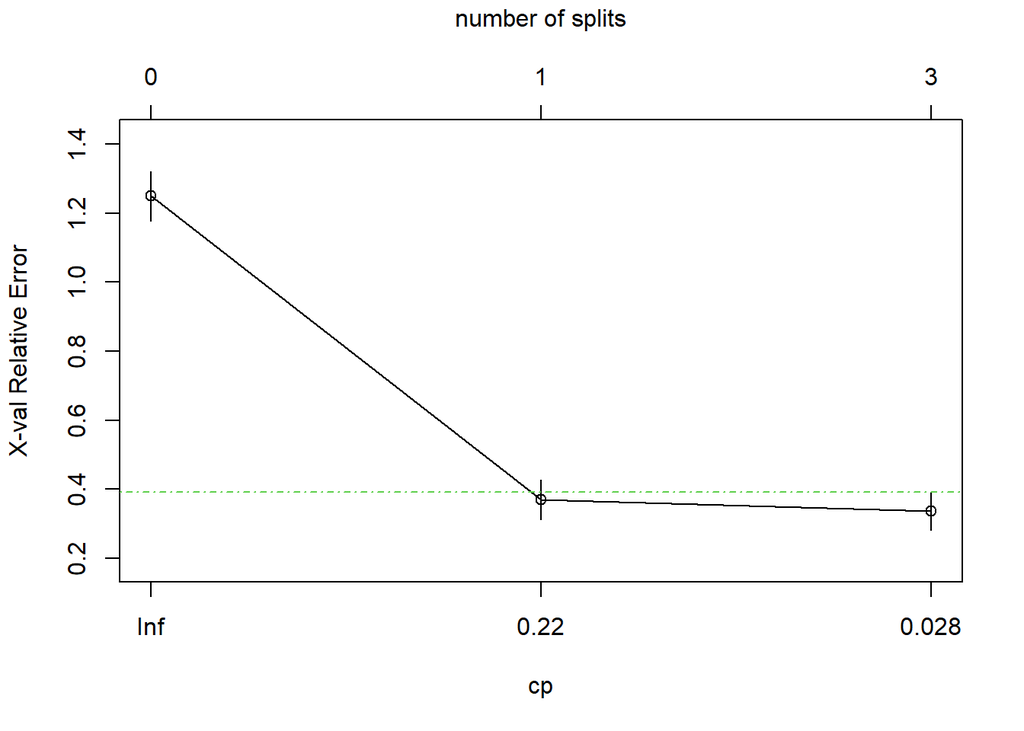

```r
plotcp(modeloAB,upper = c("splits"),lty = 10,col=3) # numero de divisiones
```

```r
printcp(modeloAB)
```

```
##
## Classification tree:
## rpart(formula = `Ganado/Perdido` ~ ., data = datent[, 2:18],
##     method = "class")
##
## Variables actually used in tree construction:
## [1] Ataque-Exc BP         Recep-Tot
##
## Root node error: 92/185 = 0.4973
##
## n= 185
##
##         CP nsplit rel error  xerror     xstd
## 1 0.630435      0   1.00000 1.25000 0.071701
## 2 0.076087      1   0.36957 0.36957 0.057260
## 3 0.010000      3   0.21739 0.33696 0.055216
```

```r
predictestAB <- predict(modeloAB,type="class", dattest[,2:17])
confutestAB<-table(dattest$`Ganado/Perdido`,predictestAB,deparse.level = 2)
confutestAB
```

```
##                         predictestAB
## dattest$`Ganado/Perdido` Perdido Ganado
##                  Perdido      34      7
##                  Ganado        5     33
```

```r
AciertoAB=round(100*mean(dattest$`Ganado/Perdido`==predictestAB),2)
SensEspecAB=round(100*diag(prop.table(confutestAB,1)),2)
c(AciertoAB, SensEspecAB)
```

```
##         Perdido  Ganado
##   84.81   82.93   86.84
```

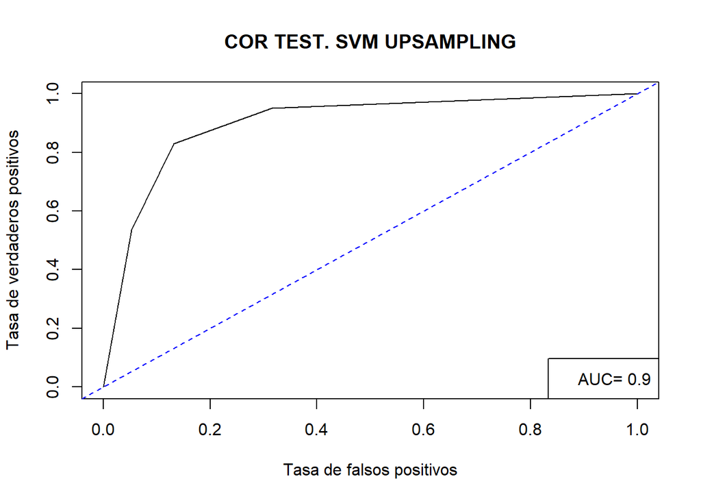

```r
probabiAB= predict(modeloAB,newdata = dat[inditest,2:17] ,
                   type="prob")[,1]
prediobjAB = prediction(probabiAB,dat[inditest,18])
plot(performance(prediobjAB, "tpr","fpr"),
     main="COR TEST. SVM UPSAMPLING",
     xlab="Tasa de falsos positivos",
     ylab="Tasa de verdaderos positivos")
abline(a=0,b=1,col="blue",lty=2)
aucAB = as.numeric(performance(prediobjAB,"auc")@y.values)
legend("bottomright",legend=paste("AUC=",round(aucAB,3)))
```

# Conclusiones

```r
Resul=rbind(Resul,c(AciertoAB,aucAB,SensEspecAB))
rownames(Resul)=c("Gauss","Kernel(Poisson)","LDA","R.Logistica","Perceptron Multicapas", "Vectores soporte","Vectores soporte con Upsampling", "Arbol de clasificacion")
Resul
```

```
##                                 Acierto       AUC     0     1
## Gauss                             84.81 0.8940950 85.37 84.21
## Kernel(Poisson)                   81.01 0.9107831 78.05 84.21
## LDA                               88.61 0.9460847 87.80 89.47
## R.Logistica                       87.34 0.9403081 90.24 84.21
## Perceptron Multicapas             89.87 0.9415918 92.68 86.84
## Vectores soporte                  87.34 0.9557125 92.68 81.58
## Vectores soporte con Upsampling   89.87 0.9505777 90.24 89.47
## Arbol de clasificacion            84.81 0.8995507 82.93 86.84
```

```r
library(pROC)
ROCtestNB1 = roc(dattest$`Ganado/Perdido`, probabi1)
ROCtestNB2 = roc(dattest$`Ganado/Perdido`, probabi2)
ROCtestLDA = roc(dattest$`Ganado/Perdido`, probabiLDA)
ROCtestPM = roc(dattest$`Ganado/Perdido`, probabiPM)
ROCtestSVM = roc(dattest$`Ganado/Perdido`, probabiSVM)
ROCtestUp = roc(dattest$`Ganado/Perdido`, probabiSVM_up)
ROCtestAB = roc(dattest$`Ganado/Perdido`, probabiAB)
```

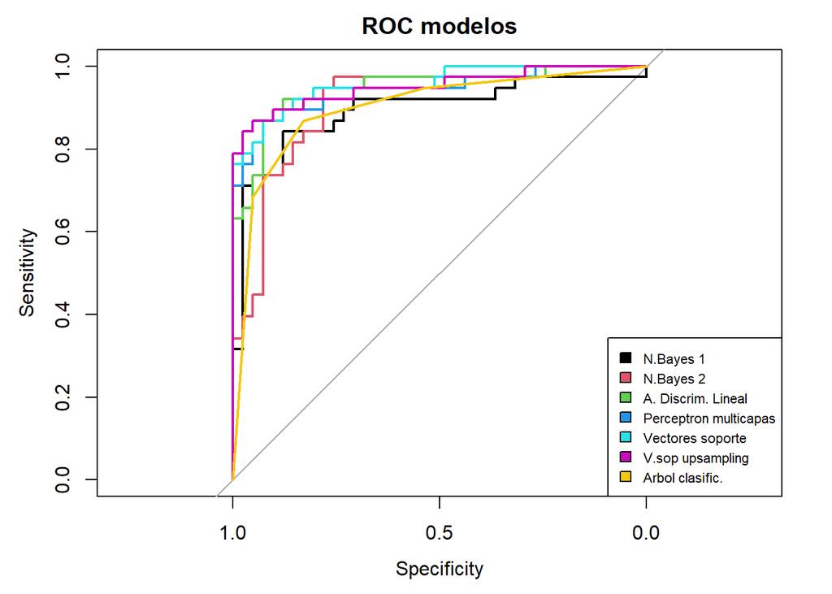

```r
plot(ROCtestNB1,col=1,lwd=2,main="ROC modelos")
lines(ROCtestNB2,col=2,lwd=2)
lines(ROCtestLDA,col=3,lwd=2)
lines(ROCtestPM,col=4,lwd=2)
lines(ROCtestSVM,col=5,lwd=2)
lines(ROCtestUp,col=6,lwd=2)
lines(ROCtestAB,col=7,lwd=2)
legend(x = "bottomright", legend = c("N.Bayes 1", "N.Bayes 2", "A. Discrim. Lineal", "Perceptron multicapas", "Vectores soporte", "V.sop upsampling", "Arbol clasific."), fill = 1:7, cex=0.7)
```